# McNally et al. Larval Biomineralization

# Visualize variance among families: Calcification

Right now this is using the mean for each jar (not all larvae measured could do that with LarvaeDat)

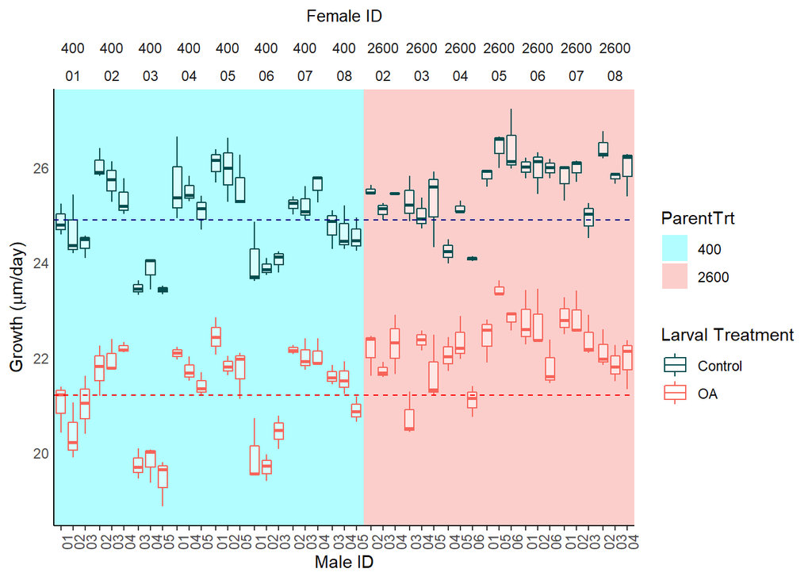

```r
#pull means for the control larvae control parents
ConConMeans<- meanJarTrt %>%
  filter(JarTrt=="Control" & ParentTrt=="400") %>%
  subset(select= c("MeanGPD", "LarvaePerimeterum", "LarvaeAreaum2",  "LarvaeDiamum"))
ConExpMeans<- meanJarTrt %>%
  filter(JarTrt=="Exposed" & ParentTrt=="400") %>%
  subset(select= c("MeanGPD", "LarvaePerimeterum", "LarvaeAreaum2",  "LarvaeDiamum"))
#EF01_EM01 only has one cross, so a boxplot won't work. Remove from the data before trying to make the plots:
LarvByJarVarVizDat<- subset(LarvByJarDat, CrossID !="EF01_EM01_B1_QG")
LarvByJarVarVizDat$ParentTrt<- factor(LarvByJarVarVizDat$ParentTrt, levels= c("400", "2600"))
ggplot(LarvByJarVarVizDat, aes(y=MeanGPD,x=as.factor(MaleIDNumber), color=JarTrt))+
  geom_boxplot(alpha=0.5, position="identity") +
  facet_grid(~ParentTrt*FemaleIDNumber, scale="free_x")+
  geom_rect(aes(xmin=-Inf, xmax=Inf, ymin=-Inf, ymax=Inf, fill = ParentTrt), colour=NA)+
  scale_fill_manual(values =c("#B1FDFF", "#FCCECB"))+
   geom_boxplot(alpha=0.5, position="identity") +
  labs(x = "Male ID", y= expression(paste("Growth (", mu, "m/day)")), title = "Female ID") +
  scale_color_manual(name = "Larval Treatment", labels = c("Control", "OA"), values = c("#004D4F", "#F7645A"))+
  geom_hline(yintercept=ConConMeans$MeanGPD, color="navyblue", lty=2)+
  geom_hline(yintercept=ConExpMeans$MeanGPD, color="red", lty=2)+
    theme_classic() +
  theme(axis.title.y.right = element_blank(),                # hide right axis title
        axis.text.y.right = element_blank(),                 # hide right axis labels
        axis.ticks.y = element_blank(),                      # hide left/right axis ticks
        axis.text.y = element_text(margin = margin(r = 0)),  # move left axis labels closer to axis
        panel.spacing = unit(0, "mm"),                    # remove spacing between facets
        strip.background = element_rect(colour="white", fill="white"), axis.text.x=element_text(angle=90),plot.title = element_text(size=10, hjust = 0.5), panel.border= element_blank())
```

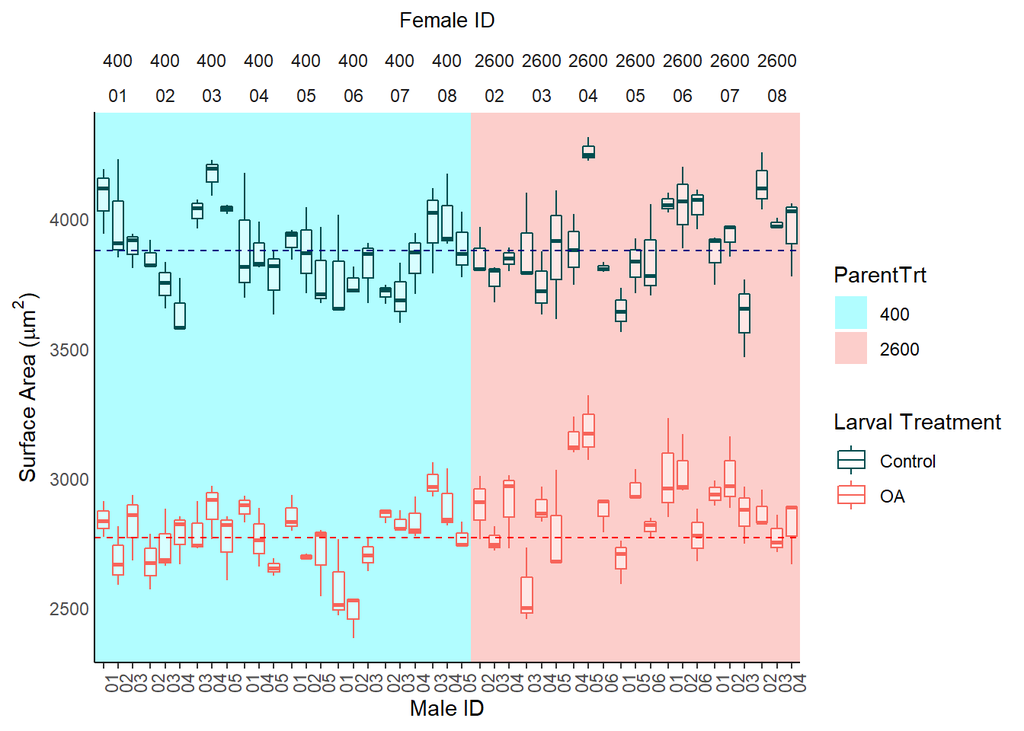

```r
ggplot(LarvByJarVarVizDat, aes(y=LarvaeAreaum2,x=as.factor(MaleIDNumber), color=JarTrt))+
  geom_boxplot(alpha=0.5, position="identity") +
  facet_grid(~ParentTrt*FemaleIDNumber, scale="free_x")+
  geom_rect(aes(xmin=-Inf, xmax=Inf, ymin=-Inf, ymax=Inf, fill = ParentTrt), colour=NA)+
  scale_fill_manual(values =c("#B1FDFF", "#FCCECB"))+
   geom_boxplot(alpha=0.5, position="identity") +
  labs(x = "Male ID", y= expression(paste("Surface Area (", mu, m^2,")")), title = "Female ID") +
  scale_color_manual(name = "Larval Treatment", labels = c("Control", "OA"), values = c("#004D4F", "#F7645A"))+
  geom_hline(aes(yintercept=ConConMeans$LarvaeAreaum2), color= "navyblue", lty=2)+
  geom_hline(aes(yintercept=ConExpMeans$LarvaeAreaum2), color= "red", lty=2)+
    theme_classic() +
  theme(axis.title.y.right = element_blank(),                # hide right axis title
        axis.text.y.right = element_blank(),                 # hide right axis labels
        axis.ticks.y = element_blank(),                      # hide left/right axis ticks
        axis.text.y = element_text(margin = margin(r = 0)),  # move left axis labels closer to axis
        panel.spacing = unit(0, "mm"),                    # remove spacing between facets
        strip.background = element_rect(colour="white", fill="white"), axis.text.x=element_text(angle=90),plot.title = element_text(size=10, hjust = 0.5), panel.border= element_blank())
```

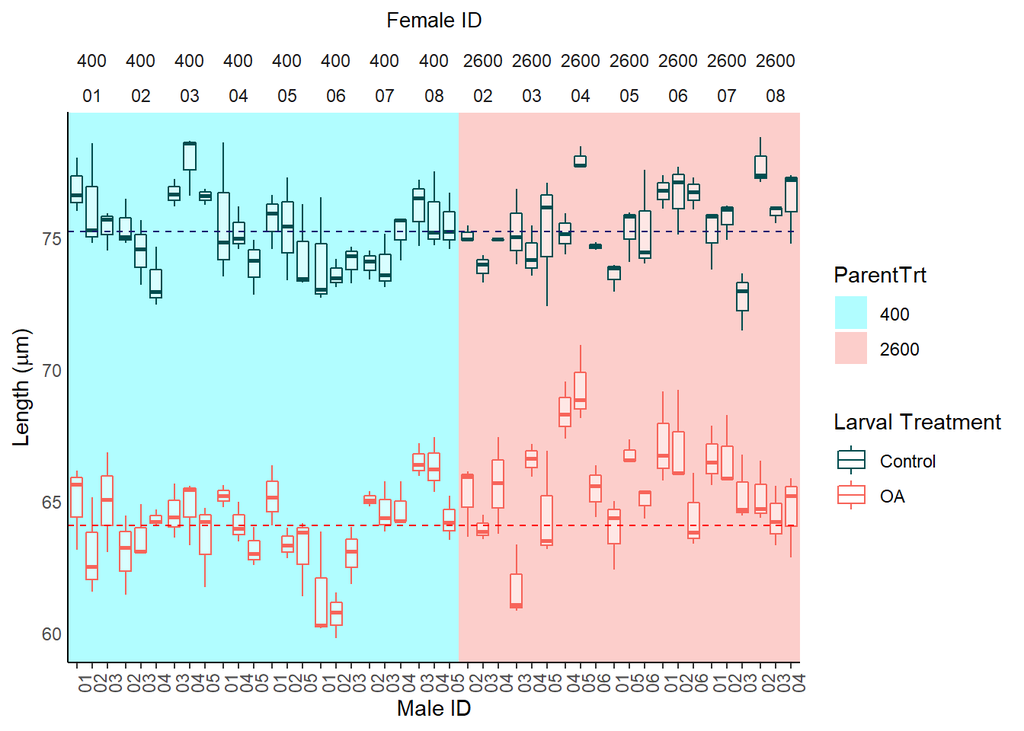

```r
ggplot(LarvByJarVarVizDat, aes(y=LarvaeDiamum ,x=MaleIDNumber, color=JarTrt))+
   geom_boxplot(alpha=0.5, position="identity") +
  facet_grid(~ParentTrt*FemaleIDNumber, scale="free_x")+
  geom_rect(aes(xmin=-Inf, xmax=Inf, ymin=-Inf, ymax=Inf, fill = ParentTrt), colour=NA)+
  scale_fill_manual(values =c("#B1FDFF", "#FCCECB"))+
   geom_boxplot(alpha=0.5, position="identity") +
  labs(x = "Male ID", y= expression(paste("Length (", mu, "m)")), title = "Female ID") +
    scale_color_manual(name = "Larval Treatment", labels = c("Control", "OA"), values = c("#004D4F", "#F7645A"))+

  geom_hline(yintercept=ConConMeans$LarvaeDiamum, color="midnightblue", lty=2)+
  geom_hline(yintercept=ConExpMeans$LarvaeDiamum, color="red", lty=2)+
    theme_classic() +
  theme(axis.title.y.right = element_blank(),                # hide right axis title
        axis.text.y.right = element_blank(),                 # hide right axis labels
        axis.ticks.y = element_blank(),                      # hide left/right axis ticks
        axis.text.y = element_text(margin = margin(r = 0)),  # move left axis labels closer to axis
        panel.spacing = unit(0, "mm"),                    # remove spacing between facets
        strip.background = element_rect(colour="white", fill="white"), axis.text.x=element_text(angle=90),plot.title = element_text(size=10, hjust = 0.5), panel.border= element_blank())
```

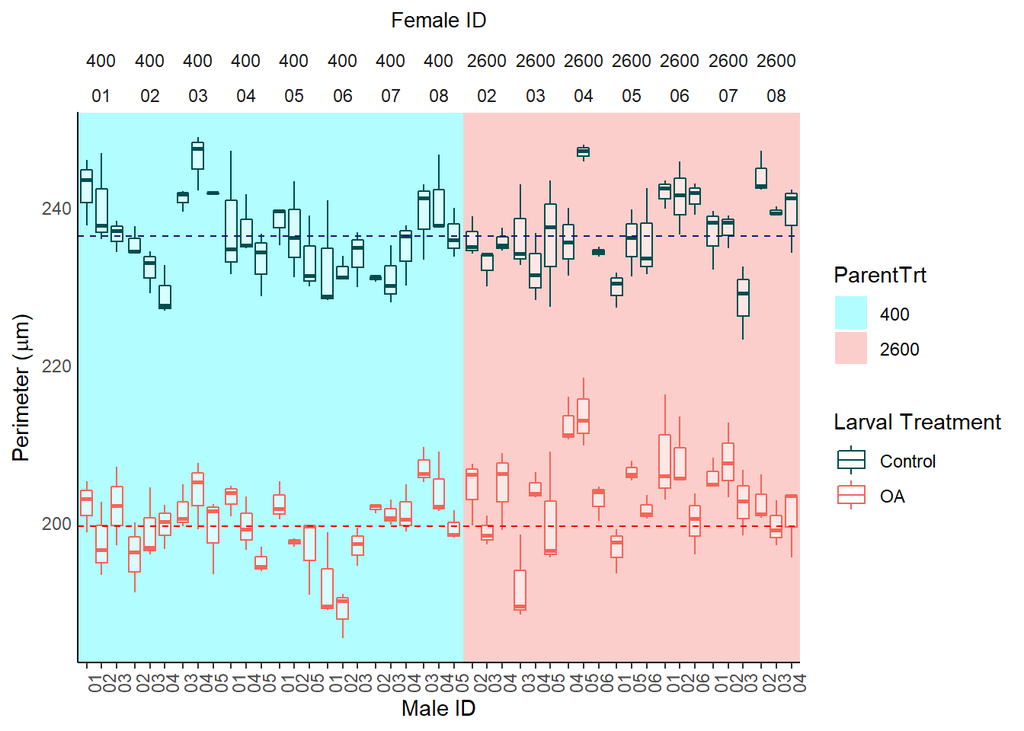

```r
ggplot(LarvByJarVarVizDat, aes(y=LarvaePerimeterum ,x=MaleIDNumber, color=JarTrt))+
    geom_boxplot(alpha=0.5, position="identity") +
  facet_grid(~ParentTrt*FemaleIDNumber, scale="free_x")+
  geom_rect(aes(xmin=-Inf, xmax=Inf, ymin=-Inf, ymax=Inf, fill = ParentTrt), colour=NA)+
  scale_fill_manual(values =c("#B1FDFF", "#FCCECB"))+
   geom_boxplot(alpha=0.5, position="identity") +
  labs(x = "Male ID", y= expression(paste("Perimeter (", mu, "m)")), title = "Female ID") +
      scale_color_manual(name = "Larval Treatment", labels = c("Control", "OA"), values = c("#004D4F", "#F7645A"))+

  geom_hline(yintercept=ConConMeans$LarvaePerimeterum, color="midnightblue", lty=2)+
  geom_hline(yintercept=ConExpMeans$LarvaePerimeterum, color="red", lty=2)+
    theme_classic() +
  theme(axis.title.y.right = element_blank(),                # hide right axis title
        axis.text.y.right = element_blank(),                 # hide right axis labels
        axis.ticks.y = element_blank(),                      # hide left/right axis ticks
        axis.text.y = element_text(margin = margin(r = 0)),  # move left axis labels closer to axis
        panel.spacing = unit(0, "mm"),                    # remove spacing between facets
        strip.background = element_rect(colour="white", fill="white"), axis.text.x=element_text(angle=90),plot.title = element_text(size=10, hjust = 0.5), panel.border= element_blank())
```

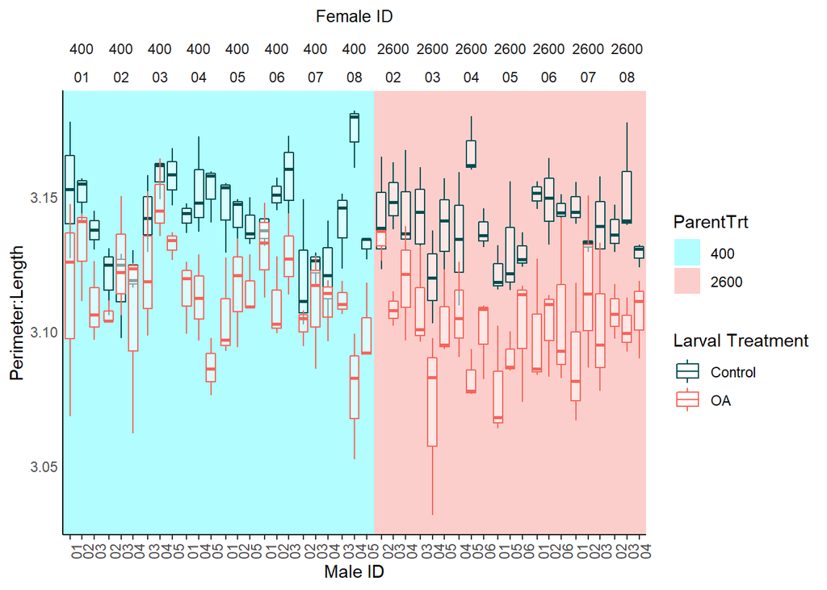

```r
ggplot(LarvByJarVarVizDat, aes(y=(LarvaePerimeterum/LarvaeDiamum),x=MaleIDNumber, color=JarTrt))+
  geom_boxplot(alpha=0.5, position="identity") +
  facet_grid(~ParentTrt*FemaleIDNumber, scale="free_x")+
  geom_rect(aes(xmin=-Inf, xmax=Inf, ymin=-Inf, ymax=Inf, fill = ParentTrt), colour=NA)+
  scale_fill_manual(values =c("#B1FDFF", "#FCCECB"))+
   geom_boxplot(alpha=0.5, position="identity") +
  labs(x = "Male ID", y= paste("Perimeter:Length"), title = "Female ID") +
    scale_color_manual(name = "Larval Treatment", labels = c("Control", "OA"), values = c("#004D4F", "#F7645A"))+
    theme_classic() +
  theme(axis.title.y.right = element_blank(),                # hide right axis title
        axis.text.y.right = element_blank(),                 # hide right axis labels
        axis.ticks.y = element_blank(),                      # hide left/right axis ticks
        axis.text.y = element_text(margin = margin(r = 0)),  # move left axis labels closer to axis
        panel.spacing = unit(0, "mm"),                    # remove spacing between facets
        strip.background = element_rect(colour="white", fill="white"), axis.text.x=element_text(angle=90),plot.title = element_text(size=10, hjust = 0.5), panel.border= element_blank())
```

# Visualize variance in a faceted way

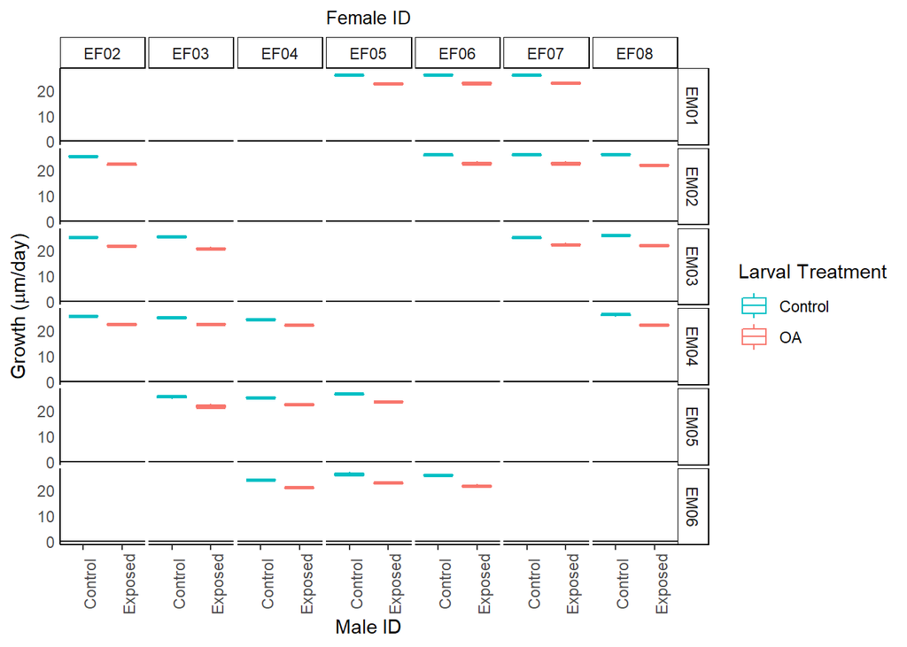

```r
#EF01_EM01 only has one cross, so a boxplot won't work. Remove from the data before trying to make the plots:
LarvByJarVarVizDat<- subset(LarvByJarDat, CrossID !="EF01_EM01_B1_QG")
Exposed.Parents<- subset(LarvByJarVarVizDat, ParentTrt=="2600")
Control.Parents<- subset(LarvByJarVarVizDat, ParentTrt=="400")
ggplot(Exposed.Parents, aes(y=MeanGPD,x=JarTrt, color=JarTrt))+
  geom_boxplot(alpha=0.5, position="identity") +
  facet_grid(MaleIDPlain~FemIDPlain, scale="free_x")+
  labs(x = "Male ID", y= expression(paste("Growth (", mu, "m/day)")), title = "Female ID") +
  scale_color_manual(name = "Larval Treatment", labels = c("Control", "OA"), values = c("#00BFC4", "#F8766D"))+
  geom_hline(yintercept=0)+
    theme_classic() +
  theme(axis.title.y.right = element_blank(),                # hide right axis title
        axis.text.y.right = element_blank(),                 # hide right axis labels
        axis.ticks.y = element_blank(),                      # hide left/right axis ticks
        axis.text.y = element_text(margin = margin(r = 0)),  # move left axis labels closer to axis
        panel.spacing = unit(0.7, "mm"),                    # remove spacing between facets
        strip.background = element_rect(size = 0.5), axis.text.x=element_text(angle=90),plot.title = element_text(size=10, hjust = 0.5))
```

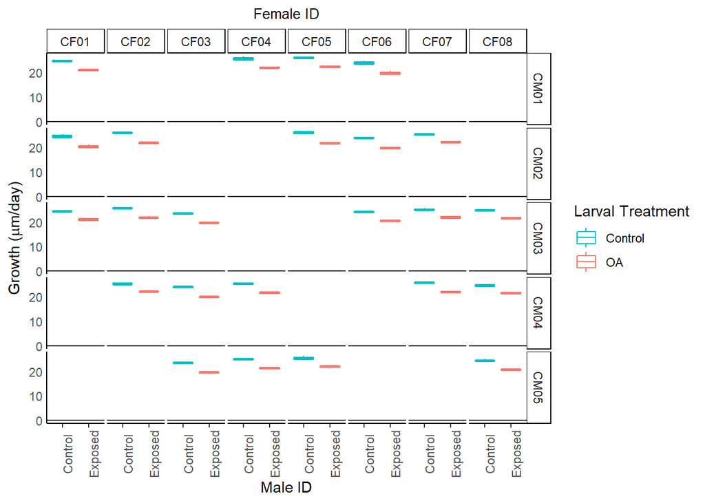

```r
ggplot(Control.Parents, aes(y=MeanGPD,x=JarTrt, color=JarTrt))+
  geom_boxplot(alpha=0.5, position="identity") +
  facet_grid(MaleIDPlain~FemIDPlain, scale="free_x")+
  labs(x = "Male ID", y= expression(paste("Growth (", mu, "m/day)")), title = "Female ID") +
  scale_color_manual(name = "Larval Treatment", labels = c("Control", "OA"), values = c("#00BFC4", "#F8766D"))+
  geom_hline(yintercept=0)+
    theme_classic() +
  theme(axis.title.y.right = element_blank(),                # hide right axis title
        axis.text.y.right = element_blank(),                 # hide right axis labels
        axis.ticks.y = element_blank(),                      # hide left/right axis ticks
        axis.text.y = element_text(margin = margin(r = 0)),  # move left axis labels closer to axis
        panel.spacing = unit(0.7, "mm"),                    # remove spacing between facets
        strip.background = element_rect(size = 0.5), axis.text.x=element_text(angle=90),plot.title = element_text(size=10, hjust = 0.5))
```

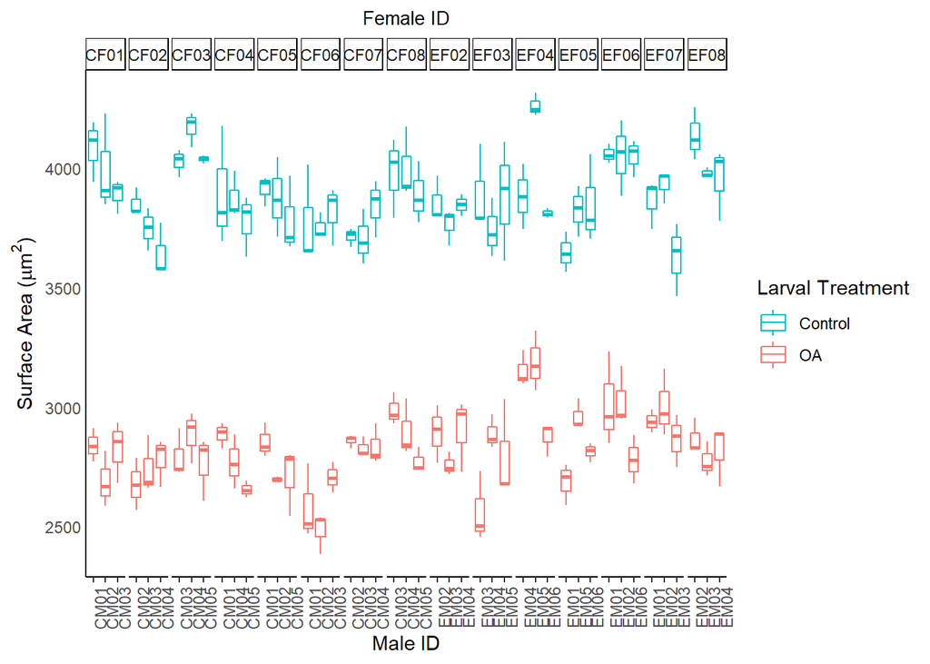

```r
#not fixed below
ggplot(LarvByJarVarVizDat, aes(y=LarvaeAreaum2,x=MaleIDPlain, color=JarTrt))+
  geom_boxplot(alpha=0.5, position="identity") +
  facet_grid(~FemIDPlain, scale="free_x")+
  labs(x = "Male ID", y= expression(paste("Surface Area (", mu, m^2,")")), title = "Female ID") +
  scale_color_manual(name = "Larval Treatment", labels = c("Control", "OA"), values = c("#00BFC4", "#F8766D"))+
    theme_classic() +
  theme(axis.title.y.right = element_blank(),                # hide right axis title
        axis.text.y.right = element_blank(),                 # hide right axis labels
        axis.ticks.y = element_blank(),                      # hide left/right axis ticks
        axis.text.y = element_text(margin = margin(r = 0)),  # move left axis labels closer to axis
        panel.spacing = unit(0.7, "mm"),                    # remove spacing between facets
        strip.background = element_rect(size = 0.5), axis.text.x=element_text(angle=90),plot.title = element_text(size=10, hjust = 0.5))
```

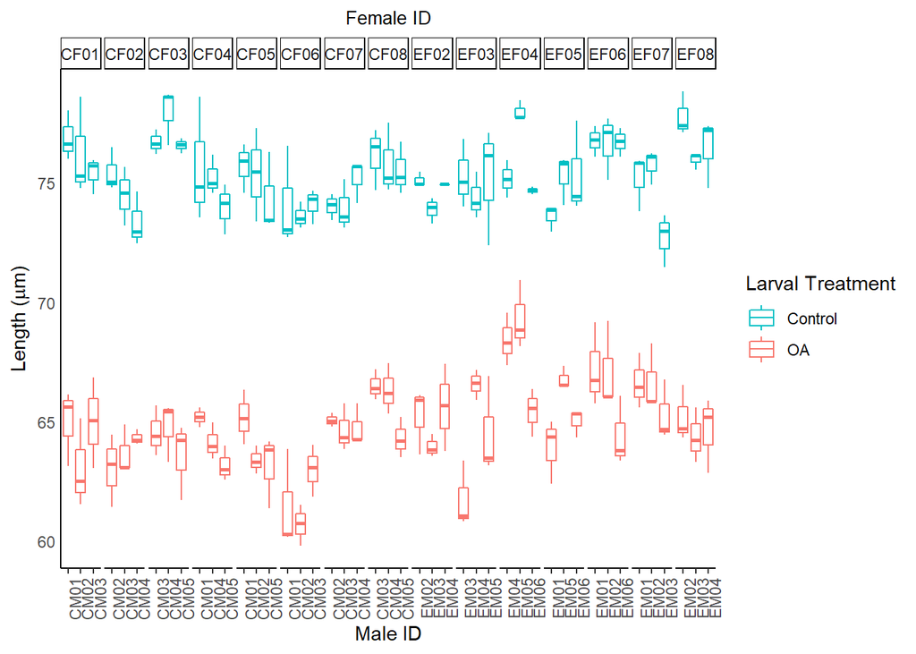

```r
ggplot(LarvByJarVarVizDat, aes(y=LarvaeDiamum ,x=MaleIDPlain, color=JarTrt))+
  geom_boxplot(alpha=0.5, position="identity") +
  facet_grid(~FemIDPlain, scale="free_x")+
  labs(x = "Male ID", y= expression(paste("Length (", mu, "m)")), title = "Female ID") +
  scale_color_manual(name = "Larval Treatment", labels = c("Control", "OA"), values = c("#00BFC4", "#F8766D"))+
    theme_classic() +
  theme(axis.title.y.right = element_blank(),                # hide right axis title
        axis.text.y.right = element_blank(),                 # hide right axis labels
        axis.ticks.y = element_blank(),                      # hide left/right axis ticks
        axis.text.y = element_text(margin = margin(r = 0)),  # move left axis labels closer to axis
        panel.spacing = unit(0.7, "mm"),                    # remove spacing between facets
        strip.background = element_rect(size = 0.5), axis.text.x=element_text(angle=90),plot.title = element_text(size=10, hjust = 0.5))
```

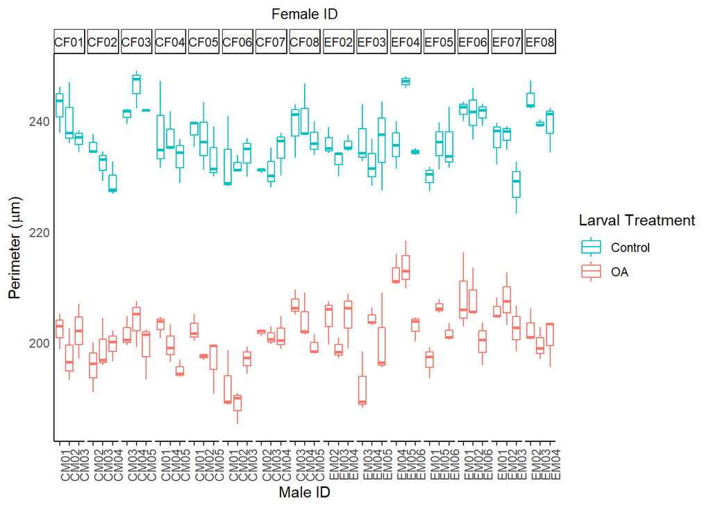

```r
ggplot(LarvByJarVarVizDat, aes(y=LarvaePerimeterum ,x=MaleIDPlain, color=JarTrt))+
  geom_boxplot(alpha=0.5, position="identity") +
  facet_grid(~FemIDPlain, scale="free_x")+
  labs(x = "Male ID", y= expression(paste("Perimeter (", mu, "m)")), title = "Female ID") +
  scale_color_manual(name = "Larval Treatment", labels = c("Control", "OA"), values = c("#00BFC4", "#F8766D"))+
    theme_classic() +
  theme(axis.title.y.right = element_blank(),                # hide right axis title
        axis.text.y.right = element_blank(),                 # hide right axis labels
        axis.ticks.y = element_blank(),                      # hide left/right axis ticks
        axis.text.y = element_text(margin = margin(r = 0)),  # move left axis labels closer to axis
        panel.spacing = unit(0.7, "mm"),                    # remove spacing between facets
        strip.background = element_rect(size = 0.5), axis.text.x=element_text(angle=90),plot.title = element_text(size=10, hjust = 0.5))
```

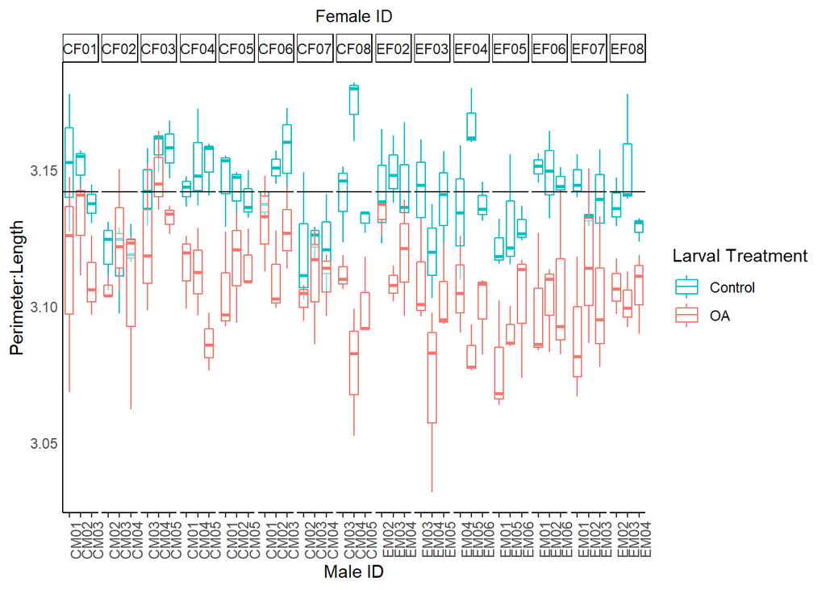

```r
ggplot(LarvByJarVarVizDat, aes(y=(LarvaePerimeterum/LarvaeDiamum),x=MaleIDPlain, color=JarTrt))+
  geom_boxplot(alpha=0.5, position="identity") +
  facet_grid(~FemIDPlain, scale="free_x")+
  labs(x = "Male ID", y= paste("Perimeter:Length"), title = "Female ID") +
  scale_color_manual(name = "Larval Treatment", labels = c("Control", "OA"), values = c("#00BFC4", "#F8766D"))+
  geom_hline(yintercept= 3.142)+
    theme_classic() +
  theme(axis.title.y.right = element_blank(),                # hide right axis title
        axis.text.y.right = element_blank(),                 # hide right axis labels
        axis.ticks.y = element_blank(),                      # hide left/right axis ticks
        axis.text.y = element_text(margin = margin(r = 0)),  # move left axis labels closer to axis
        panel.spacing = unit(0.7, "mm"),                    # remove spacing between facets
        strip.background = element_rect(size = 0.5), axis.text.x=element_text(angle=90),plot.title = element_text(size=10, hjust = 0.5))
```

Visualize larval survival

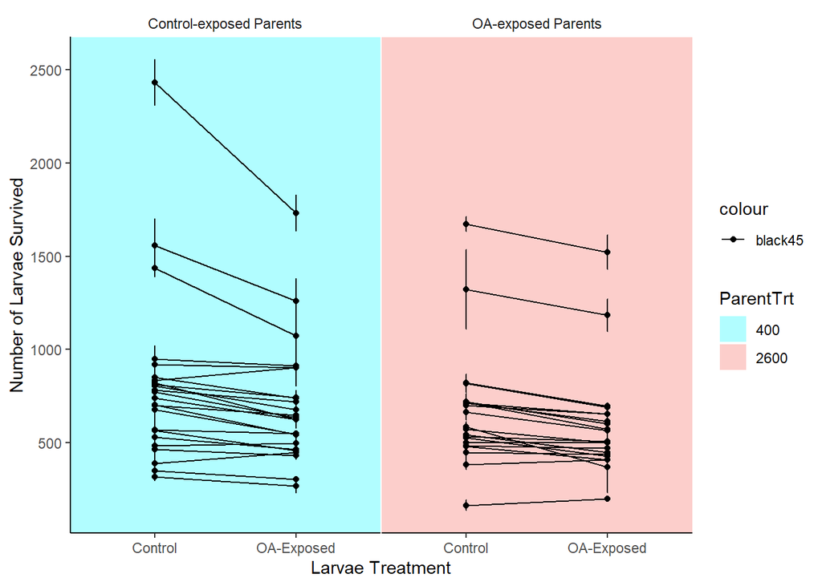

```r
SurvDat$ParentTrt<- factor(SurvDat$ParentTrt, levels=c("400", "2600"))
MeanSurvDat<- ddply(SurvWideDat, .(ParentTrt), numcolwise(mean, na.rm=T))
MeanSurvDat$ParentTrt<- factor(MeanSurvDat$ParentTrt, levels= c("400", "2600"))
SESurvDat<- ddply(SurvWideDat, .(ParentTrt), numcolwise(se, na.rm=T))
SESurvDat$ParentTrt<- factor(SESurvDat$ParentTrt, levels= c("400", "2600"))
#make reaction norms for survival color will be parent treatment. X will be jar treatment. Each cross will be its own line
ParTreat<- c("400"="Control-exposed Parents", "2600"="OA-exposed Parents")
LarvTreat<- c("Control"= "Control", "Exposed" = "OA-Exposed")
ggplot(SurvDat,aes(x=JarTrt, y=LarvaeSurvived, color = "black45", group= CrossID)) +
  geom_rect(aes(xmin=-Inf, xmax=Inf, ymin=-Inf, ymax=Inf, fill = ParentTrt), colour=NA)+
  scale_fill_manual(values =c("#B1FDFF", "#FCCECB"))+
    geom_point(aes(color="black45"))+
  geom_line(aes(color="black45", group=CrossID))+
  scale_x_discrete(labels=LarvTreat)+
  geom_errorbar(aes(ymin= LarvaeSurvived-SELarvaeSurvived, ymax=LarvaeSurvived+SELarvaeSurvived),width=0.05, position=position_dodge(0))+
    labs(x = "Larvae Treatment", y = "Number of Larvae Survived") +
  scale_color_manual(values="black")+

  facet_grid(.~ParentTrt, labeller =labeller(ParentTrt = ParTreat))+
  theme_classic() +
  theme(panel.spacing = unit(0.2, "mm"),                    # remove spacing between facets
        strip.background = element_rect(colour="white", fill="white"), panel.border= element_blank())
```

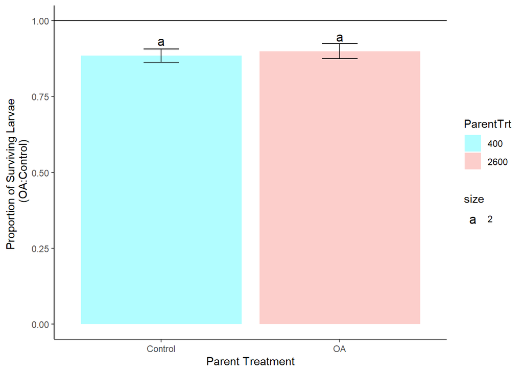

```r
#make bar graph of survival
ggplot(data = MeanSurvDat, aes(x = ParentTrt, y = RatSurv, fill=ParentTrt)) +
  geom_bar(stat="identity", position="dodge")+
  ylim(c(0,1))+
  geom_hline(yintercept=1)+
  geom_errorbar(aes(ymin= RatSurv-SESurvDat$RatSurv, ymax=RatSurv+SESurvDat$RatSurv),width=0.2, position=position_dodge(.9))+
  labs(x = "Parent Treatment", y = "Proportion of Surviving Larvae \n (OA:Control)") +
  scale_x_discrete(breaks=c("400","2600"),
        labels=c("Control", "OA"))+
  scale_fill_manual(values =c("#B1FDFF", "#FCCECB"))+
   geom_text(aes(label=c("a", "a"),
            position = 3,
            size=2), vjust = -1)+
  theme_classic()
```

## Visualize variance in survival by family

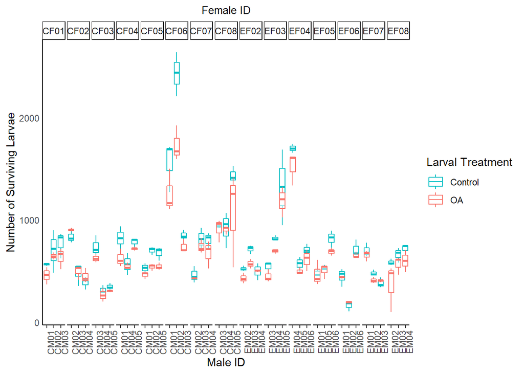

```r
#get percent differences in survival.
SurvWideDat$OACont_Perc<- (SurvWideDat$MeanLarvSurvivedExp-SurvWideDat$MeanLarvSurvivedCon)/SurvWideDat$MeanLarvSurvivedCon

ggplot(LarvByJarVarVizDat, aes(y=LarvaeSurvived,x=MaleIDPlain, color=JarTrt))+
  geom_boxplot(alpha=0.5, position="identity") +
  facet_grid(~FemIDPlain, scale="free_x")+
  labs(x = "Male ID", y= paste("Number of Surviving Larvae"), title = "Female ID") +
  scale_color_manual(name = "Larval Treatment", labels = c("Control", "OA"), values = c("#00BFC4", "#F8766D"))+
    theme_classic() +
  theme(axis.title.y.right = element_blank(),                # hide right axis title
        axis.text.y.right = element_blank(),                 # hide right axis labels
        axis.ticks.y = element_blank(),                      # hide left/right axis ticks
        axis.text.y = element_text(margin = margin(r = 0)),  # move left axis labels closer to axis
        panel.spacing = unit(0.7, "mm"),                    # remove spacing between facets
        strip.background = element_rect(size = 0.5), axis.text.x=element_text(angle=90),plot.title = element_text(size=10, hjust = 0.5))
```

# Look at trade offs between growth and survival

# Survival ratio and GPD in exposed conditions

```r
ConFams<- subset(SurvWideDat, ParentTrt=="400")
ExpFams<- subset(SurvWideDat, ParentTrt=="2600")

#do Type II regression with data from each parent treatment separately
#I will use an OLS method and have MeanGPDExp be the y variable because it has the largest error.
EPmodlm<- lmodel2(RatSurv~MeanGPDExp, data=ExpFams, nperm= 1000)
```

```
## RMA was not requested: it will not be computed.
```

```r
EPmodlmsimp<- lm(RatSurv~1, data=ExpFams)
par(mfcol=c(2,2))
plot(EPmodlm)
EPmodlmcon<- lmodel2(RatSurv~MeanGPDExp, data=ConFams, nperm=1000)
```

```
## RMA was not requested: it will not be computed.
```

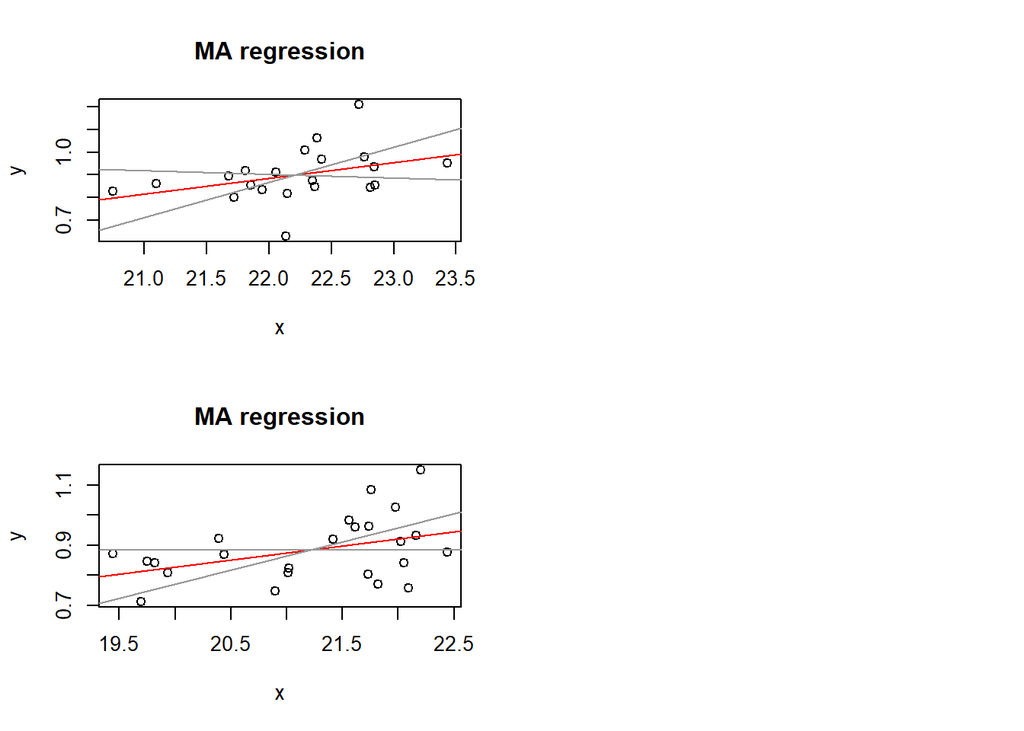

```r
EPmodlmconsimp<- lm(RatSurv~1, data=ConFams)

plot(EPmodlmcon)
par(mfcol=c(1,1))
```

```r
EPmodlm
```

```
##
## Model II regression
##
## Call: lmodel2(formula = RatSurv ~ MeanGPDExp, data = ExpFams, nperm =
## 1000)
##
## n = 21   r = 0.3619745   r-square = 0.1310255
## Parametric P-values:   2-tailed = 0.1068681    1-tailed = 0.05343403
## Angle between the two OLS regression lines = 23.31732 degrees
##
## Permutation tests of OLS, MA, RMA slopes: 1-tailed, tail corresponding to sign
## A permutation test of r is equivalent to a permutation test of the OLS slope
## P-perm for SMA = NA because the SMA slope cannot be tested
##
## Regression results
##   Method  Intercept      Slope Angle (degrees) P-perm (1-tailed)
## 1    OLS -0.5940708 0.06723306        3.846382        0.05894106
## 2     MA -0.6400006 0.06930100        3.964316        0.05894106
## 3    SMA -3.2261595 0.18573978       10.522197                NA
##
## Confidence intervals
##   Method 2.5%-Intercept 97.5%-Intercept  2.5%-Slope 97.5%-Slope
## 1    OLS      -2.441312        1.253171 -0.01590615   0.1503723
## 2     MA      -2.561717        1.259050 -0.01620156   0.1558240
## 3    SMA      -5.467135       -1.774015  0.12035869   0.2866371
##
## Eigenvalues: 0.3843617 0.01141614
##
## H statistic used for computing C.I. of MA: 0.007273835
```

```r
EPmodlmcon
```

```
##
## Model II regression
##
## Call: lmodel2(formula = RatSurv ~ MeanGPDExp, data = ConFams, nperm =
## 1000)
##
## n = 24   r = 0.4081405   r-square = 0.1665787
## Parametric P-values:   2-tailed = 0.04771255    1-tailed = 0.02385627
## Angle between the two OLS regression lines = 12.94061 degrees
##
## Permutation tests of OLS, MA, RMA slopes: 1-tailed, tail corresponding to sign
## A permutation test of r is equivalent to a permutation test of the OLS slope
## P-perm for SMA = NA because the SMA slope cannot be tested
##
## Regression results
##   Method  Intercept      Slope Angle (degrees) P-perm (1-tailed)
## 1    OLS -0.1018317 0.04652294        2.663648        0.02397602
## 2     MA -0.1126087 0.04703112        2.692701        0.02397602
## 3    SMA -1.5325751 0.11398757        6.502939                NA
##
## Confidence intervals
##   Method 2.5%-Intercept 97.5%-Intercept   2.5%-Slope 97.5%-Slope
## 1    OLS      -1.078513       0.8748495 0.0005120520  0.09253383
## 2     MA      -1.102261       0.8727280 0.0005689947  0.09369674
## 3    SMA      -2.697848      -0.7463132 0.0769125338  0.16893431
##
## Eigenvalues: 0.8814235 0.009503111
##
## H statistic used for computing C.I. of MA: 0.002153964
```

```r
EPmodlmconTidy<- tidy(EPmodlmcon)
```

```
## Error in tidy(EPmodlmcon): could not find function "tidy"
```

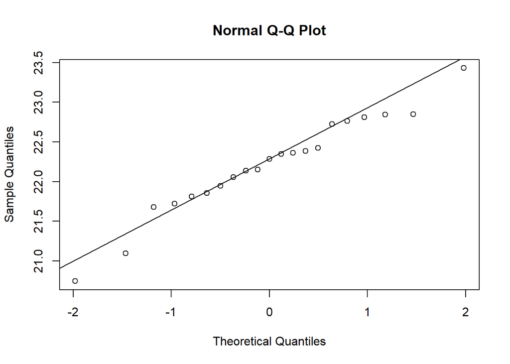

```r
qqnorm(ExpFams$MeanGPDExp)
qqline(ExpFams$MeanGPDExp)
```

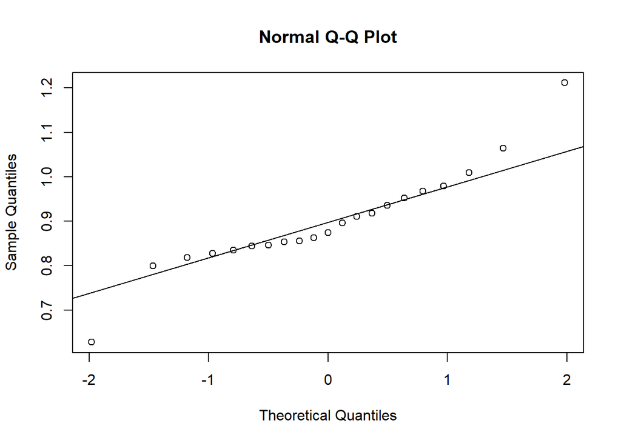

```r
qqnorm(ExpFams$RatSurv)
qqline(ExpFams$RatSurv)
```

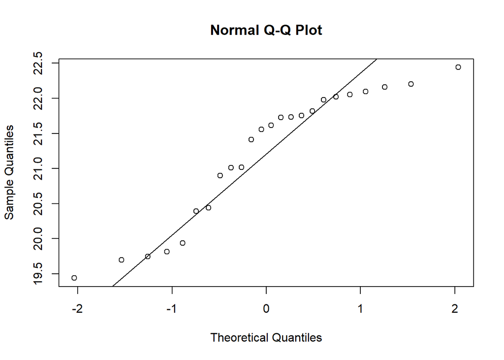

```r
qqnorm(ConFams$MeanGPDExp)
qqline(ConFams$MeanGPDExp)
```

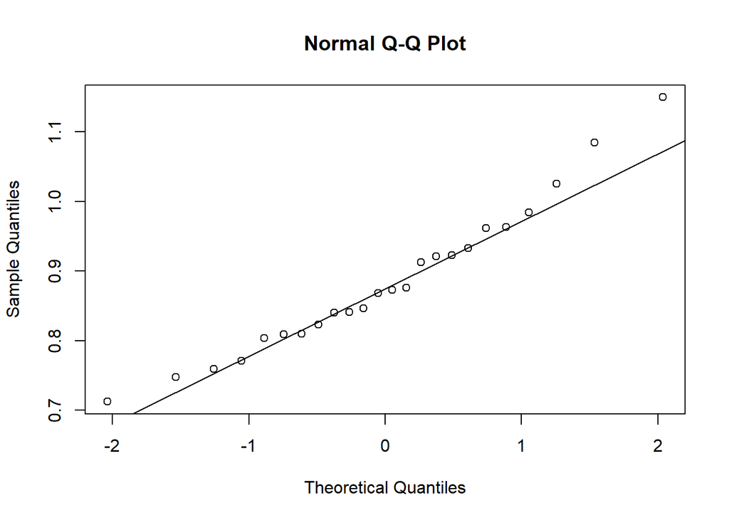

```r
qqnorm(ConFams$RatSurv)
qqline(ConFams$RatSurv)
```

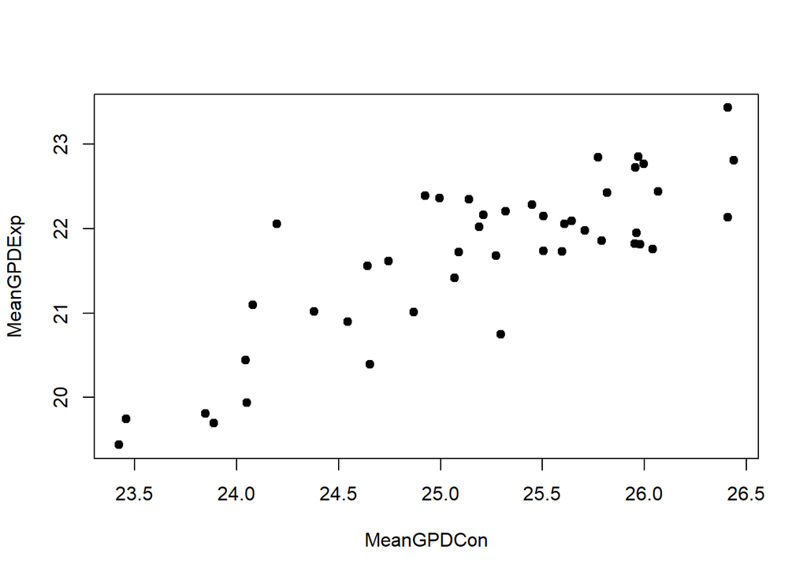

```r
plot(MeanGPDExp~MeanGPDCon, data=SurvWideDat, pch=19)
```

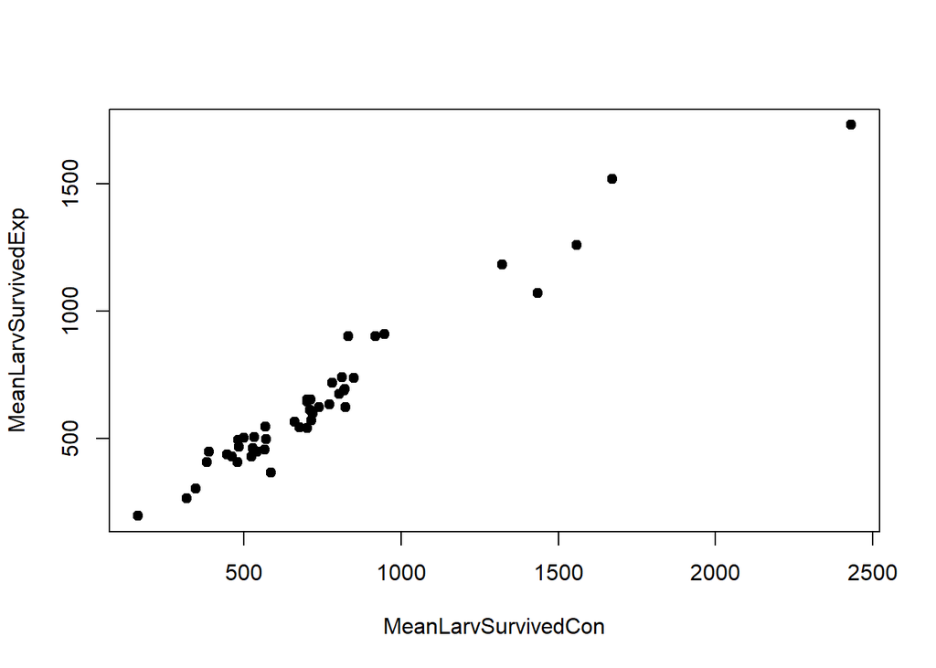

```r
plot(MeanLarvSurvivedExp~MeanLarvSurvivedCon, data=SurvWideDat, pch=19)
```

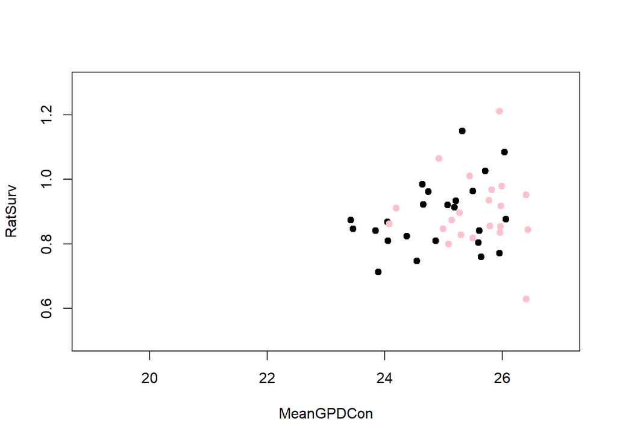

```r
plot(RatSurv~MeanGPDCon, data=ConFams, pch=19, ylim=c(.5,1.3), xlim=c(19,27))
points(RatSurv~MeanGPDCon, data=ExpFams, pch=19, col="pink")
```

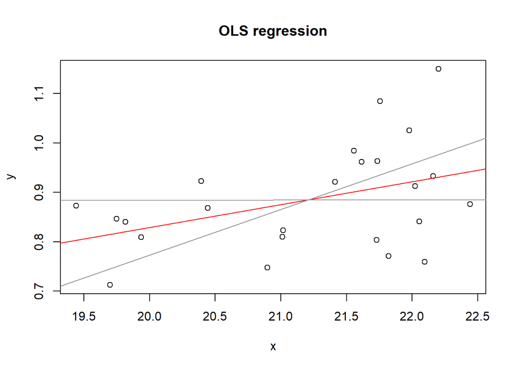

```r
plot(EPmodlmcon, "OLS")
```

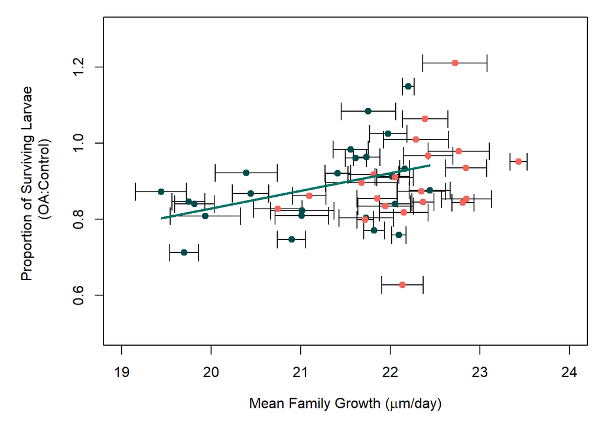

```r
par(mar=c(5,6,1,1), mfrow=c(1,1), xpd=F)
plot(RatSurv~MeanGPDExp, data=ConFams, pch=19, col="#007367",ylim=c(.5,1.3), xlim=c(19,24), xlab= expression(paste("Mean Family Growth (", mu, "m/day)")), ylab="Proportion of Surviving Larvae \n (OA:Control)")
arrows(x0=(SurvWideDat$MeanGPDExp-SurvWideDat$SEMeanGPDCExp), x1= (SurvWideDat$MeanGPDExp+SurvWideDat$SEMeanGPDCExp), y0 = SurvWideDat$RatSurv, y1= SurvWideDat$RatSurv, code=3, angle=90, len=.1)
points(RatSurv~MeanGPDExp, data=ConFams, pch=19, col="#004D4F")
points(RatSurv~MeanGPDExp, data=ExpFams, pch=19, col="#F7645A")
ablineclip(a=-0.1018317, b=0.04652294, x1=min(ConFams$MeanGPDExp), x2=max(ConFams$MeanGPDExp), col="#007367", lwd=2.5)
par(xpd=TRUE)
legend.enhanced("topright",
   c("Control", "OA-exposed"),
   pch=19,
   col=c("#004D4F","#F7645A"),
   bty="n",
   title="Parent Treatment",
   horiz=TRUE,
   y.intersp=.7,
   x.intersp=0.5,
   title.adj=c(.5,0),
   title.col="black",
   seg.len =1,
   cex=.7,
   yjust=0.5,
   text.font = NULL,
   inset = c(0,-.15)
   )
```

Export Figures

Do simple t-tests on the means for oa-exposed and control exposed parents within each larvae treatment

```r
#get Bonferoni adjusted p-crit:
0.05/10
```

```
## [1] 0.005
```

```r
Lexp<- subset(LarvaeDat, JarTrt=="Exposed")
Lcon<- subset(LarvaeDat, JarTrt=="Control")

t.test(GrowthPerDay~ParentTrt, data=Lexp, var.equal=TRUE)
```

```
##
##  Two Sample t-test
##
## data:  GrowthPerDay by ParentTrt
## t = 14.02, df = 1346, p-value < 2.2e-16
## alternative hypothesis: true difference in means is not equal to 0
## 95 percent confidence interval:
##  0.862121 1.142634
## sample estimates:
## mean in group 2600  mean in group 400
##           22.20969           21.20731
```

```r
t.test(GrowthPerDay~ParentTrt, data=Lcon, var.equal=TRUE)
```

```
##
##  Two Sample t-test
##
## data:  GrowthPerDay by ParentTrt
## t = 10.775, df = 1348, p-value < 2.2e-16
## alternative hypothesis: true difference in means is not equal to 0
## 95 percent confidence interval:
##  0.5319790 0.7688096
## sample estimates:
## mean in group 2600  mean in group 400
##           25.54475           24.89436
```

```r
t.test(LarvaeDiamum~ParentTrt, data=Lexp, var.equal=TRUE)
```

```
##
##  Two Sample t-test
##
## data:  LarvaeDiamum by ParentTrt
## t = 8.1796, df = 1346, p-value = 6.522e-16
## alternative hypothesis: true difference in means is not equal to 0
## 95 percent confidence interval:
##  1.174311 1.915293
## sample estimates:
## mean in group 2600  mean in group 400
##            65.6224            64.0776
```

```r
t.test(LarvaeDiamum~ParentTrt, data=Lcon, var.equal=TRUE)#not significantly different for control larvae
```

```
##
##  Two Sample t-test
##
## data:  LarvaeDiamum by ParentTrt
## t = 1.4748, df = 1348, p-value = 0.1405
## alternative hypothesis: true difference in means is not equal to 0
## 95 percent confidence interval:
##  -0.07356676  0.51920840
## sample estimates:
## mean in group 2600  mean in group 400
##           75.46671           75.24389
```

```r
t.test(sqrt(LarvaeAreaum2)~ParentTrt, data=Lexp, var.equal=TRUE)
```

```
##
##  Two Sample t-test
##
## data:  sqrt(LarvaeAreaum2) by ParentTrt
## t = 7.0498, df = 1346, p-value = 2.855e-12
## alternative hypothesis: true difference in means is not equal to 0
## 95 percent confidence interval:
##  0.7557342 1.3384891
## sample estimates:
## mean in group 2600  mean in group 400
##           53.63310           52.58599
```

```r
t.test(sqrt(LarvaeAreaum2)~ParentTrt, data=Lcon, var.equal=TRUE) #not significantly different for control larvae
```

```
##
##  Two Sample t-test
##
## data:  sqrt(LarvaeAreaum2) by ParentTrt
## t = 1.483, df = 1348, p-value = 0.1383
## alternative hypothesis: true difference in means is not equal to 0
## 95 percent confidence interval:
##  -0.06172545  0.44418997
## sample estimates:
## mean in group 2600  mean in group 400
##           62.40781           62.21658
```

```r
t.test(LarvaePerimeterum~ParentTrt, data=Lexp, var.equal=TRUE)
```

```
##
##  Two Sample t-test
##
## data:  LarvaePerimeterum by ParentTrt
## t = 7.1895, df = 1346, p-value = 1.075e-12
## alternative hypothesis: true difference in means is not equal to 0
## 95 percent confidence interval:
##  2.917762 5.107556
## sample estimates:
## mean in group 2600  mean in group 400
##           203.5199           199.5072
```

```r
t.test(LarvaePerimeterum~ParentTrt, data=Lcon, var.equal=TRUE) #not significantly different for control larvae
```

```
##
##  Two Sample t-test
##
## data:  LarvaePerimeterum by ParentTrt
## t = 1.2371, df = 1348, p-value = 0.2163
## alternative hypothesis: true difference in means is not equal to 0
## 95 percent confidence interval:
##  -0.3601831  1.5899445
## sample estimates:
## mean in group 2600  mean in group 400
##           236.9926           236.3777
```

```r
t.test(PerimLenRat~ParentTrt, data=Lexp, var.equal=TRUE)
```

```
##
##  Two Sample t-test
##
## data:  PerimLenRat by ParentTrt
## t = -3.936, df = 1346, p-value = 8.71e-05
## alternative hypothesis: true difference in means is not equal to 0
## 95 percent confidence interval:
##  -0.017865978 -0.005980582
## sample estimates:
## mean in group 2600  mean in group 400
##           3.102418           3.114341
```

```r
t.test(PerimLenRat~ParentTrt, data=Lcon, var.equal=TRUE)#not significantly different for control larvae
```

```
##
##  Two Sample t-test
##
## data:  PerimLenRat by ParentTrt
## t = -0.47893, df = 1348, p-value = 0.6321
## alternative hypothesis: true difference in means is not equal to 0
## 95 percent confidence interval:
##  -0.005393581  0.003276831
## sample estimates:
## mean in group 2600  mean in group 400
##           3.140449           3.141508
```

## Protocol versions check

Run survival model with just the data for protocol 1 and then just the data from protocol 2 and compare the results to the actual output. Steps: 1) subset the data by protocol 2) get Sfams for prot 1 and prot 2 data 3) run the survival analysis

```r
#1 subset the data by protocol
Prot1<- subset(LarvByJarDat, ProtocolVersion == "1")
Prot2<- subset(LarvByJarDat, ProtocolVersion != "1")

SurvDatProt1<- ddply(Prot1, .(CrossID, ParentTrt, JarTrt, MaleID, FemaleID, TrtTankID,MaleTrtTankID, AccTankID, Block), numcolwise(mean, na.rm=TRUE))
SESurvDatProt1<- ddply(Prot1, .(CrossID, ParentTrt, JarTrt, Block), numcolwise(se, na.rm=TRUE)) #get the standard errors for each mean count
SESurvDatProt1<- subset(SESurvDatProt1, select= c(CrossID, JarTrt, LarvaeSurvived, SatArag_ATDIC, JarSatArg_Total, MeanGPD)) #select only certain columns.
colnames(SESurvDatProt1)<- paste("SE", colnames(SESurvDatProt1), sep="")
#merge the standard error data to the SurvDat dataframe
SurvDatProt1<- merge(SurvDatProt1, SESurvDatProt1, by.x= c("CrossID", "JarTrt"), by.y= c("SECrossID", "SEJarTrt"))
#only keep the relevant fields because otherwise this is a huge data frame
SurvDatProt1<- subset(SurvDatProt1, select= c(CrossID, JarTrt, ParentTrt, MaleID, FemaleID, TrtTankID,MaleTrtTankID, AccTankID, LarvaeSurvived, Block, SELarvaeSurvived, SatArag_ATDIC, MeanGPD, SEMeanGPD))
SurvDatProt1<- subset(SurvDatProt1, Block=="B1" & CrossID !="")
#use the spread function to go from long form to wide form for the survival data

SurvDatToWideProt1<- unite(SurvDatProt1, Value, c(LarvaeSurvived, SELarvaeSurvived, MeanGPD, SEMeanGPD), sep="_")
SurvWideDatProt1<- spread(SurvDatToWideProt1, JarTrt, value= Value)
#now split the mean and SE apart again
SurvWideDatProt1<- separate(SurvWideDatProt1, Control, into= c("MeanLarvSurvivedCon", "SELarvSurvivedCon", "MeanGPDCon", "SEMeanGPDCon"), sep="_")
SurvWideDatProt1<- separate(SurvWideDatProt1, Exposed, into= c("MeanLarvSurvivedExp", "SELarvSurvivedExp", "MeanGPDExp", "SEMeanGPDCExp"), sep="_")
#make the means and ses numeric
SurvWideDatProt1$MeanLarvSurvivedExp<- as.numeric(SurvWideDatProt1$MeanLarvSurvivedExp)
SurvWideDatProt1$MeanLarvSurvivedCon<- as.numeric(SurvWideDatProt1$MeanLarvSurvivedCon)
SurvWideDatProt1$SELarvSurvivedExp<- as.numeric(SurvWideDatProt1$SELarvSurvivedExp)
SurvWideDatProt1$SELarvSurvivedCon<- as.numeric(SurvWideDatProt1$SELarvSurvivedCon)
SurvWideDatProt1$MeanGPDCon<- as.numeric(SurvWideDatProt1$MeanGPDCon)
SurvWideDatProt1$MeanGPDExp<- as.numeric(SurvWideDatProt1$MeanGPDExp)
SurvWideDatProt1$SEMeanGPDCon<- as.numeric(SurvWideDatProt1$SEMeanGPDCon)
SurvWideDatProt1$SEMeanGPDCExp<- as.numeric(SurvWideDatProt1$SEMeanGPDCExp)
SurvWideDatProt1$RatSurv<- SurvWideDatProt1$MeanLarvSurvivedExp/SurvWideDatProt1$MeanLarvSurvivedCon
SurvWideDatProt1$RatGPD<- SurvWideDatProt1$MeanGPDExp/SurvWideDatProt1$MeanGPDCon
SurvWideDatProt1$SurvChange<- (SurvWideDatProt1$MeanLarvSurvivedCon-SurvWideDatProt1$MeanLarvSurvivedExp)/SurvWideDatProt1$MeanLarvSurvivedCon
SurvWideDatProt1$CrossID<- as.factor(SurvWideDatProt1$CrossID)
SurvWideDatProt1$FemaleID<- as.factor(SurvWideDatProt1$FemaleID)
SurvWideDatProt1$MaleID<- as.factor(SurvWideDatProt1$MaleID)

SurvDatProt2<- ddply(Prot2, .(CrossID, ParentTrt, JarTrt, MaleID, FemaleID, TrtTankID,MaleTrtTankID, AccTankID, Block), numcolwise(mean, na.rm=TRUE))
SESurvDatProt2<- ddply(Prot2, .(CrossID, ParentTrt, JarTrt, Block), numcolwise(se, na.rm=TRUE)) #get the standard errors for each mean count
SESurvDatProt2<- subset(SESurvDatProt2, select= c(CrossID, JarTrt, LarvaeSurvived, SatArag_ATDIC, JarSatArg_Total, MeanGPD)) #select only certain columns.
colnames(SESurvDatProt2)<- paste("SE", colnames(SESurvDatProt2), sep="")
#merge the standard error data to the SurvDat dataframe
SurvDatProt2<- merge(SurvDatProt2, SESurvDatProt2, by.x= c("CrossID", "JarTrt"), by.y= c("SECrossID", "SEJarTrt"))
#only keep the relevant fields because otherwise this is a huge data frame
SurvDatProt2<- subset(SurvDatProt2, select= c(CrossID, JarTrt, ParentTrt, MaleID, FemaleID, TrtTankID,MaleTrtTankID, AccTankID, LarvaeSurvived, Block, SELarvaeSurvived, SatArag_ATDIC, MeanGPD, SEMeanGPD))
SurvDatProt2<- subset(SurvDatProt2, Block=="B1" & CrossID !="")
#use the spread function to go from long form to wide form for the survival data

SurvDatToWideProt2<- unite(SurvDatProt2, Value, c(LarvaeSurvived, SELarvaeSurvived, MeanGPD, SEMeanGPD), sep="_")
SurvWideDatProt2<- spread(SurvDatToWideProt2, JarTrt, value= Value)
#now split the mean and SE apart again
SurvWideDatProt2<- separate(SurvWideDatProt2, Control, into= c("MeanLarvSurvivedCon", "SELarvSurvivedCon", "MeanGPDCon", "SEMeanGPDCon"), sep="_")
SurvWideDatProt2<- separate(SurvWideDatProt2, Exposed, into= c("MeanLarvSurvivedExp", "SELarvSurvivedExp", "MeanGPDExp", "SEMeanGPDCExp"), sep="_")
#make the means and ses numeric
SurvWideDatProt2$MeanLarvSurvivedExp<- as.numeric(SurvWideDatProt2$MeanLarvSurvivedExp)
SurvWideDatProt2$MeanLarvSurvivedCon<- as.numeric(SurvWideDatProt2$MeanLarvSurvivedCon)
SurvWideDatProt2$SELarvSurvivedExp<- as.numeric(SurvWideDatProt2$SELarvSurvivedExp)
SurvWideDatProt2$SELarvSurvivedCon<- as.numeric(SurvWideDatProt2$SELarvSurvivedCon)
SurvWideDatProt2$MeanGPDCon<- as.numeric(SurvWideDatProt2$MeanGPDCon)
SurvWideDatProt2$MeanGPDExp<- as.numeric(SurvWideDatProt2$MeanGPDExp)
SurvWideDatProt2$SEMeanGPDCon<- as.numeric(SurvWideDatProt2$SEMeanGPDCon)
SurvWideDatProt2$SEMeanGPDCExp<- as.numeric(SurvWideDatProt2$SEMeanGPDCExp)
SurvWideDatProt2$RatSurv<- SurvWideDatProt2$MeanLarvSurvivedExp/SurvWideDatProt2$MeanLarvSurvivedCon
SurvWideDatProt2$RatGPD<- SurvWideDatProt2$MeanGPDExp/SurvWideDatProt2$MeanGPDCon
SurvWideDatProt2$SurvChange<- (SurvWideDatProt2$MeanLarvSurvivedCon-SurvWideDatProt2$MeanLarvSurvivedExp)/SurvWideDatProt2$MeanLarvSurvivedCon
SurvWideDatProt2$CrossID<- as.factor(SurvWideDatProt2$CrossID)
SurvWideDatProt2$FemaleID<- as.factor(SurvWideDatProt2$FemaleID)
SurvWideDatProt2$MaleID<- as.factor(SurvWideDatProt2$MaleID)

#stats on protocol 1 data
par(mfcol=c(1,1))
surv1_prot1<- lmer(RatSurv~ParentTrt+ (1|FemaleID)+(1|MaleID)+(1|TrtTankID)+(1|MaleTrtTankID), data=SurvWideDatProt1)
```

```
## boundary (singular) fit: see ?isSingular
```

```r
survstepFE_prot1<- step(surv1_prot1)
```

```
## boundary (singular) fit: see ?isSingular
## boundary (singular) fit: see ?isSingular
## boundary (singular) fit: see ?isSingular
## boundary (singular) fit: see ?isSingular
```

```r
print(survstepFE_prot1)
```

```
## Backward reduced random-effect table:
##
##                     Eliminated npar logLik     AIC    LRT Df Pr(>Chisq)
## <none>                            7 14.716 -15.432
## (1 | TrtTankID)              1    6 14.716 -17.432 0.0000  1    0.99996
## (1 | MaleTrtTankID)          2    5 14.715 -19.430 0.0011  1    0.97326
## (1 | MaleID)                 3    4 14.440 -20.879 0.5514  1    0.45773
## (1 | FemaleID)               0    3 10.684 -15.367 7.5117  1    0.00613 **
## ---
## Signif. codes:  0 '***' 0.001 '**' 0.01 '*' 0.05 '.' 0.1 ' ' 1
##
## Backward reduced fixed-effect table:
## Degrees of freedom method: Satterthwaite
##
##           Eliminated     Sum Sq    Mean Sq NumDF DenDF F value Pr(>F)
## ParentTrt          1 0.00055147 0.00055147     1    13  0.0308 0.8634
##
## Model found:
## RatSurv ~ (1 | FemaleID)
```

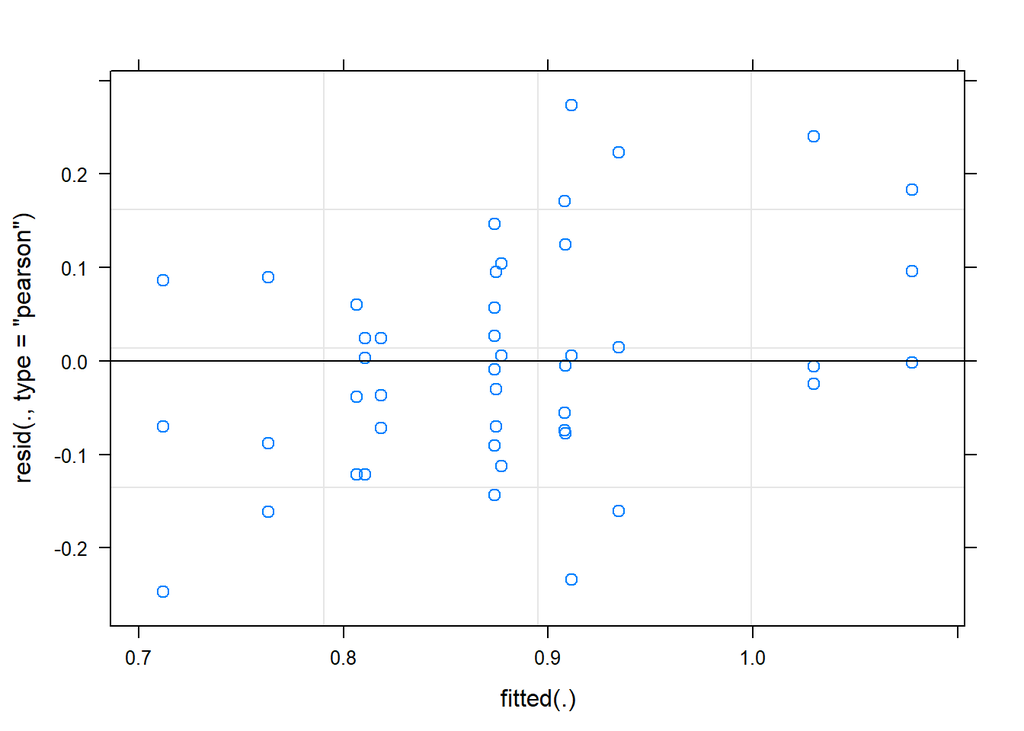

```r
survfin_prot1<- lmer(RatSurv~ (1|FemaleID), data=SurvWideDatProt1)#final model chosen by step function: RatSurv~ (1|FemaleID)
plot(survfin_prot1)
```

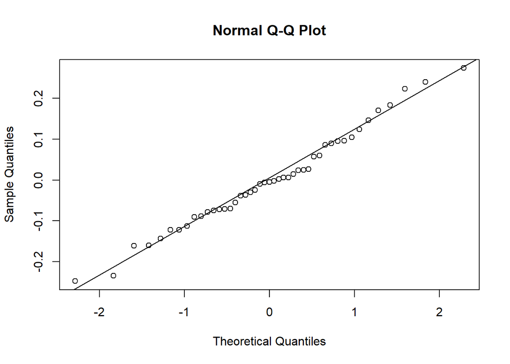

```r
qqnorm(resid(survfin_prot1))
qqline(resid(survfin_prot1))
```

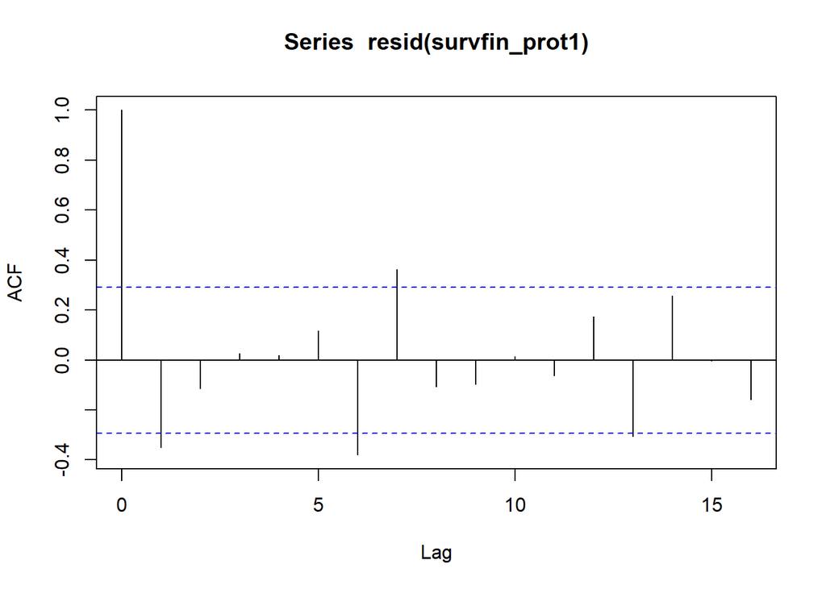

```r
acf(resid(survfin_prot1))
```

```r
summary(survfin_prot1)
```

```
## Linear mixed model fit by REML. t-tests use Satterthwaite's method [
## lmerModLmerTest]
## Formula: RatSurv ~ (1 | FemaleID)
##    Data: SurvWideDatProt1
##
## REML criterion at convergence: -32.3
##
## Scaled residuals:
##      Min       1Q   Median       3Q      Max
## -1.84866 -0.55615 -0.03665  0.64166  2.04720
##
## Random effects:
##  Groups   Name        Variance Std.Dev.
##  FemaleID (Intercept) 0.01285  0.1134
##  Residual             0.01789  0.1338
## Number of obs: 45, groups:  FemaleID, 15
##
## Fixed effects:
##             Estimate Std. Error       df t value Pr(>|t|)
## (Intercept)  0.87861    0.03542 14.00000    24.8 5.71e-13 ***
## ---
## Signif. codes:  0 '***' 0.001 '**' 0.01 '*' 0.05 '.' 0.1 ' ' 1
```

```r
#try to see if this is significantly different for exposed vs control larval treatment
SurvOA_prot1<- subset(SurvWideDatProt1, ParentTrt=="2600")
SurvCon_prot1<- subset(SurvWideDatProt1, ParentTrt=="400")
t.test(SurvOA_prot1$RatSurv, mu = 1, alternative = "two.sided")
```

```
##
##  One Sample t-test
##
## data:  SurvOA_prot1$RatSurv
## t = -3.1831, df = 20, p-value = 0.004673
## alternative hypothesis: true mean is not equal to 1
## 95 percent confidence interval:
##  0.8104679 0.9605365
## sample estimates:
## mean of x
## 0.8855022
```

```r
t.test(SurvCon_prot1$RatSurv, mu = 1, alternative = "two.sided")
```

```
##
##  One Sample t-test
##
## data:  SurvCon_prot1$RatSurv
## t = -3.3854, df = 23, p-value = 0.002547
## alternative hypothesis: true mean is not equal to 1
## 95 percent confidence interval:
##  0.7947252 0.9504412
## sample estimates:
## mean of x
## 0.8725832
```

```r
#stats for protocol 2
par(mfcol=c(1,1))
surv1_Prot2<- lmer(RatSurv~ParentTrt+ (1|FemaleID)+(1|MaleID)+(1|TrtTankID)+(1|MaleTrtTankID), data=SurvWideDatProt2)
```

```
## boundary (singular) fit: see ?isSingular
```

```r
survstepFE_Prot2<- step(surv1_Prot2)
```

[output not shown]

[output not shown]

```r
print(survstepFE_Prot2)
```

[output not shown]

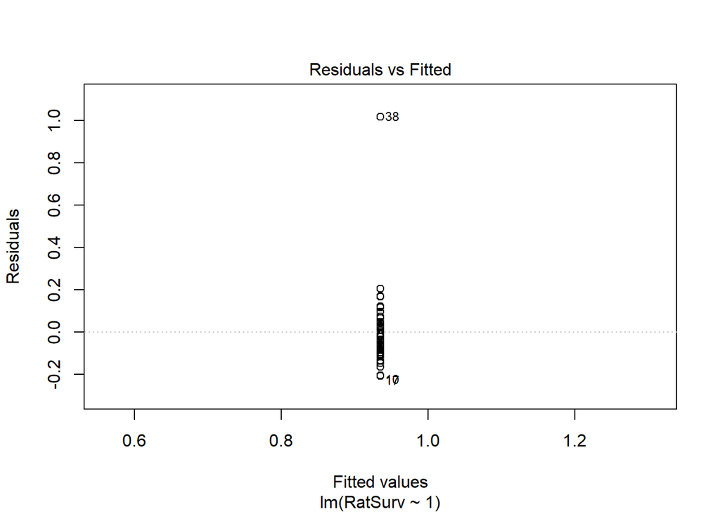

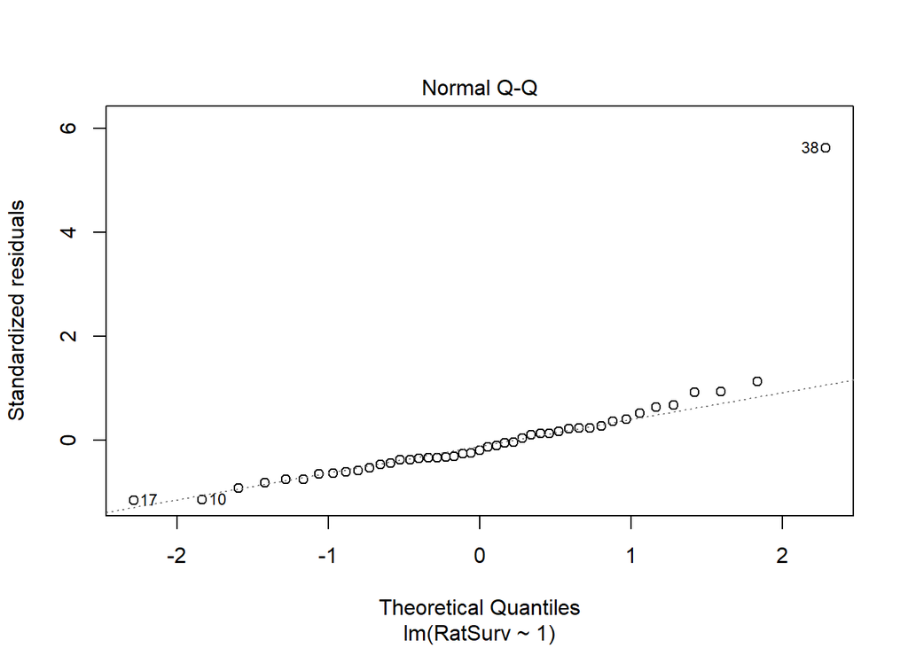

```
## hat values (leverages) are all = 0.02222222
##  and there are no factor predictors; no plot no. 5
```

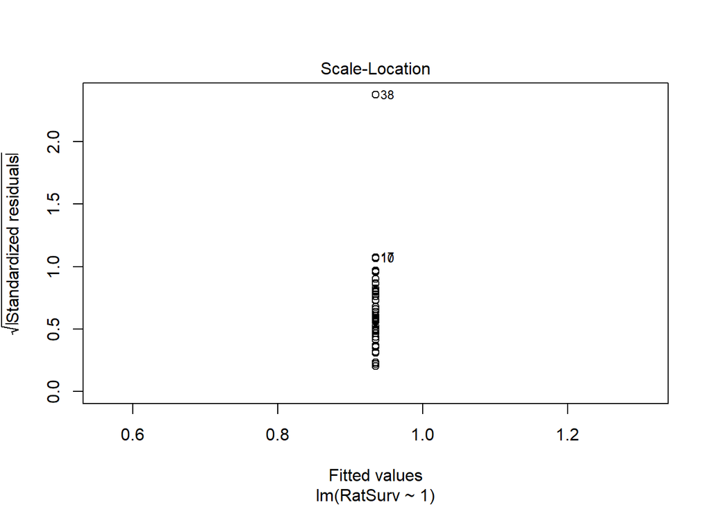

```r
#did not choose an lmer model so it is just ~1

survfin_Prot2<- lm(RatSurv~ 1, data=SurvWideDatProt2)#final model chosen by step function: RatSurv~ (1|FemaleID)
plot(survfin_Prot2)
```

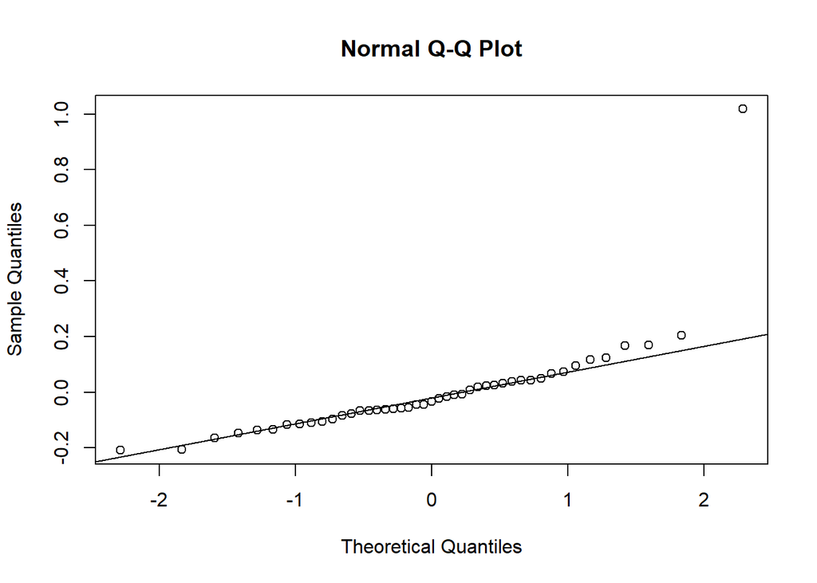

```r
qqnorm(resid(survfin_Prot2))
qqline(resid(survfin_Prot2))
```

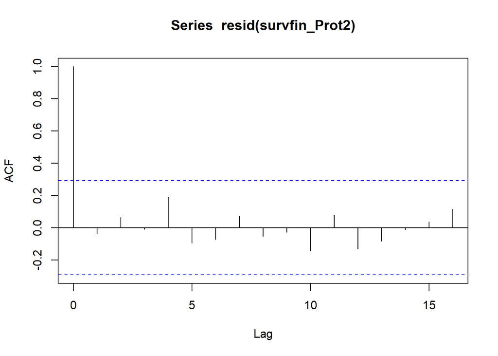

```r
acf(resid(survfin_Prot2))
```

```r
summary(survfin_Prot2)
```

```
##
## Call:
## lm(formula = RatSurv ~ 1, data = SurvWideDatProt2)
##
## Residuals:
##      Min       1Q   Median       3Q      Max
## -0.20875 -0.08316 -0.03419  0.04218  1.01795
##
## Coefficients:
##             Estimate Std. Error t value Pr(>|t|)
## (Intercept)  0.93488    0.02724   34.32   <2e-16 ***
## ---
## Signif. codes:  0 '***' 0.001 '**' 0.01 '*' 0.05 '.' 0.1 ' ' 1
##
## Residual standard error: 0.1827 on 44 degrees of freedom
```

```r
#try to see if this is significantly different for exposed vs control larval treatment
SurvOA_Prot2<- subset(SurvWideDatProt2, ParentTrt=="2600")
SurvCon_Prot2<- subset(SurvWideDatProt2, ParentTrt=="400")
t.test(SurvOA_Prot2$RatSurv, mu = 1, alternative = "two.sided")
```

```
##
##  One Sample t-test
##
## data:  SurvOA_Prot2$RatSurv
## t = -0.77402, df = 20, p-value = 0.448
## alternative hypothesis: true mean is not equal to 1
## 95 percent confidence interval:
##  0.8453538 1.0709398
## sample estimates:
## mean of x
## 0.9581468
```

```r
t.test(SurvCon_Prot2$RatSurv, mu = 1, alternative = "two.sided")
```

```
##
##  One Sample t-test
##
## data:  SurvCon_Prot2$RatSurv
## t = -4.2847, df = 23, p-value = 0.0002769
## alternative hypothesis: true mean is not equal to 1
## 95 percent confidence interval:
##  0.8732395 0.9557860
## sample estimates:
## mean of x
## 0.9145127
```

```r
#without the outlier
SurvOA_Prot2sub<- subset(SurvOA_Prot2, CrossID != "EF06_EM02_B1_QG")
t.test(SurvOA_Prot2sub$RatSurv, mu = 1, alternative = "two.sided")
```

```
##
##  One Sample t-test
##
## data:  SurvOA_Prot2sub$RatSurv
## t = -4.1052, df = 19, p-value = 0.0006025
## alternative hypothesis: true mean is not equal to 1
## 95 percent confidence interval:
##  0.8617171 0.9551081
## sample estimates:
## mean of x
## 0.9084126
```

```r
SurvWideDatProt2sub<- subset(SurvWideDatProt2, CrossID != "EF06_EM02_B1_QG")
surv1_Prot2sub<- lmer(RatSurv~ParentTrt+ (1|FemaleID)+(1|MaleID)+(1|TrtTankID)+(1|MaleTrtTankID), data=SurvWideDatProt2sub)
```

```
## boundary (singular) fit: see ?isSingular
```

```r
survstepFE_Prot2sub<- step(surv1_Prot2sub)
```

```
## boundary (singular) fit: see ?isSingular
## boundary (singular) fit: see ?isSingular
## boundary (singular) fit: see ?isSingular
```

[output not shown]

```r
print(survstepFE_Prot2sub)
```

[output not shown]

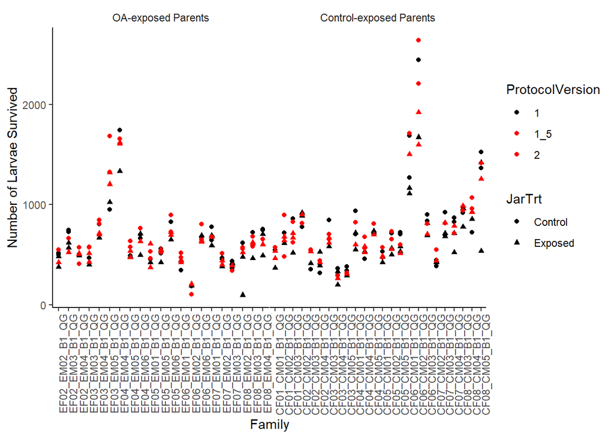

```r
ggplot(LarvByJarDat,aes(x=CrossID, y=LarvaeSurvived, color = ProtocolVersion, shape= JarTrt)) +
    geom_point(aes(color=ProtocolVersion))+
    labs(x = "Family", y = "Number of Larvae Survived") +
  scale_color_manual(values=c("black", "red", "red"))+

  facet_grid(.~ParentTrt, labeller =labeller(ParentTrt = ParTreat), scale="free_x" )+
  theme_classic() +
  theme(panel.spacing = unit(0.2, "mm"),                    # remove spacing between facets
        strip.background = element_rect(colour="white", fill="white"), panel.border= element_blank(),axis.text.x = element_text(angle = 90))
```

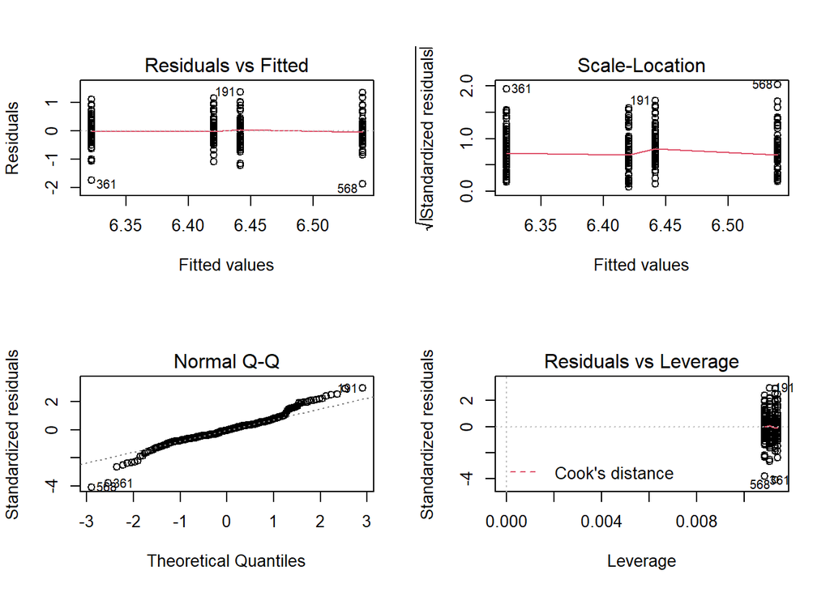

```r
LarvByJarDat$ProtFixed<- ifelse(LarvByJarDat$ProtocolVersion=="1_5", paste("2"), paste(LarvByJarDat$ProtocolVersion))
anovmod<- aov(log(LarvaeSurvived)~ProtFixed+JarTrt, data=LarvByJarDat)
par(mfcol=c(2,2))
plot(anovmod)
```

```r
summary(anovmod)
```

```
##              Df Sum Sq Mean Sq F value Pr(>F)
## ProtFixed     1   0.66  0.6618   3.107 0.0791 .
## JarTrt        1   0.96  0.9589   4.502 0.0348 *
## Residuals   266  56.65  0.2130
## ---
## Signif. codes:  0 '***' 0.001 '**' 0.01 '*' 0.05 '.' 0.1 ' ' 1
```

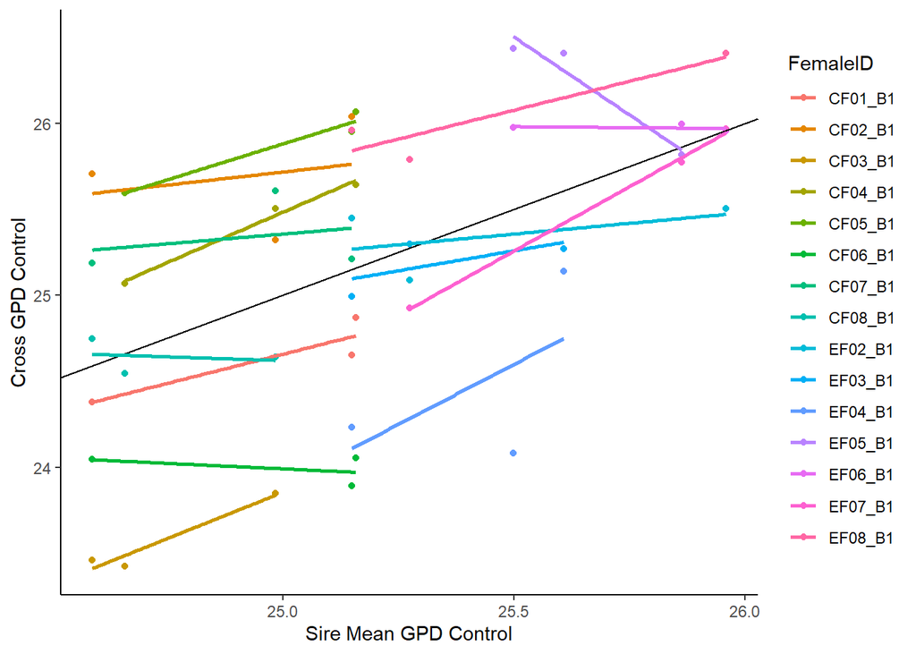

```r
par(mfcol=c(1,1), xpd=F)
#get mean for each dam and each sire growth per day
SireMeans<- ddply(LarvaeDat, .(MaleID, JarTrt), numcolwise(mean, na.rm=T))
DamMeans<- ddply(LarvaeDat, .(FemaleID, JarTrt), numcolwise(mean, na.rm=T))

SireMeansCont<- filter(SireMeans, JarTrt=="Control")
SireMeansExp<- filter(SireMeans, JarTrt=="Exposed")
DamMeansCont<- filter(DamMeans, JarTrt=="Control")
DamMeansExp<- filter(DamMeans, JarTrt=="Exposed")

#add these to the larvaedat data frame
LarvByJarVarVizDat$SireGPDCont<- SireMeansCont$GrowthPerDay[match(LarvByJarVarVizDat$MaleID, SireMeansCont$MaleID)]
LarvByJarVarVizDat$SireGPDExp<- SireMeansExp$GrowthPerDay[match(LarvByJarVarVizDat$MaleID, SireMeansExp$MaleID)]
LarvByJarVarVizDat$DamGPDCont<- DamMeansCont$GrowthPerDay[match(LarvByJarVarVizDat$FemaleID, DamMeansCont$FemaleID)]
LarvByJarVarVizDat$DamGPDExp<- DamMeansExp$GrowthPerDay[match(LarvByJarVarVizDat$FemaleID, DamMeansExp$FemaleID)]

FamMeansWide$MaleID<- LarvByJarDat$MaleID[match(FamMeansWide$CrossID, LarvByJarDat$CrossID)]
FamMeansWide$FemaleID<- LarvByJarDat$FemaleID[match(FamMeansWide$CrossID, LarvByJarDat$CrossID)]
FamMeansWide$SireGPDCont<- SireMeansCont$GrowthPerDay[match(FamMeansWide$MaleID, SireMeansCont$MaleID)]
FamMeansWide$SireGPDExp<- SireMeansExp$GrowthPerDay[match(FamMeansWide$MaleID, SireMeansExp$MaleID)]
FamMeansWide$DamGPDCont<- DamMeansCont$GrowthPerDay[match(FamMeansWide$FemaleID, DamMeansCont$FemaleID)]
FamMeansWide$DamGPDExp<- DamMeansExp$GrowthPerDay[match(FamMeansWide$FemaleID, DamMeansExp$FemaleID)]

ggplot(FamMeansWide, aes(y=MeanGPD_Control, x=SireGPDCont, color= FemaleID))+
  geom_point()+
  geom_abline(slope=1, intercept=0)+
  geom_smooth(method=lm, se=FALSE, fullrange=F)+
   labs(x = "Sire Mean GPD Control", y= "Cross GPD Control") +
  theme_classic()
```

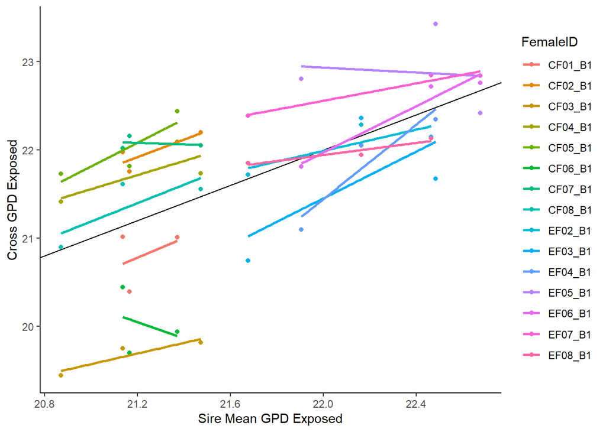

```r
ggplot(FamMeansWide, aes(y=MeanGPD_Exposed, x=SireGPDExp, color= FemaleID))+
  geom_point()+
  geom_abline(slope=1, intercept=0)+
  geom_smooth(method=lm, se=FALSE, fullrange=F)+
   labs(x = "Sire Mean GPD Exposed", y= "Cross GPD Exposed") +
  theme_classic()
```

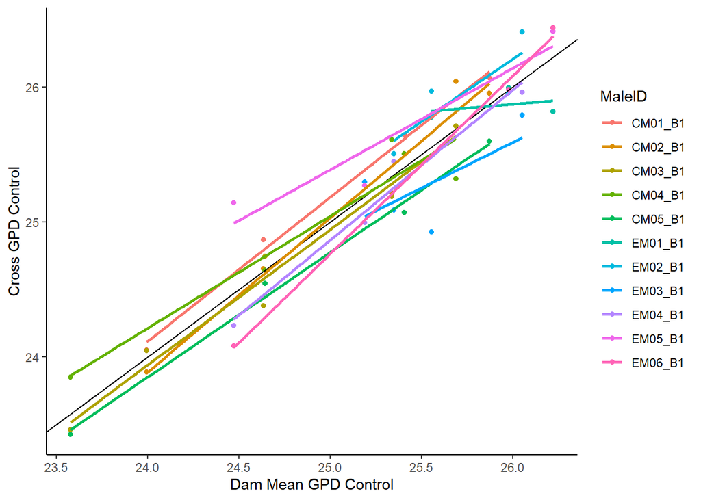

```r
ggplot(FamMeansWide, aes(y=MeanGPD_Control, x=DamGPDCont, color= MaleID))+
  geom_point()+
  geom_abline(slope=1, intercept=0)+
  geom_smooth(method=lm, se=FALSE, fullrange=F)+
   labs(x = "Dam Mean GPD Control", y= "Cross GPD Control") +
  theme_classic()
```

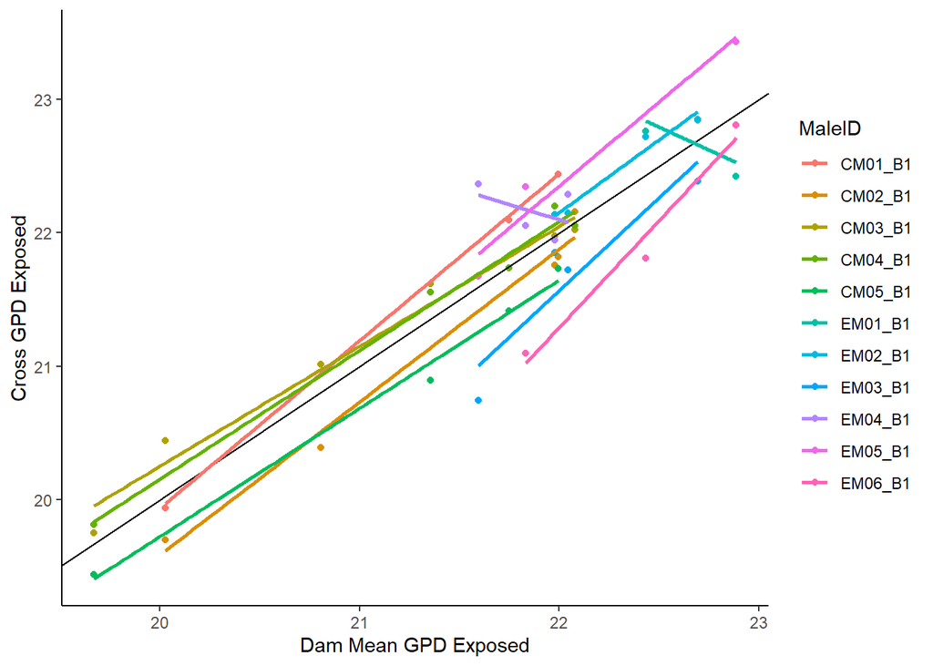

```r
ggplot(FamMeansWide, aes(y=MeanGPD_Exposed, x=DamGPDExp, color= MaleID))+
  geom_point()+
  geom_abline(slope=1, intercept=0)+
  geom_smooth(method=lm, se=FALSE, fullrange=F)+
   labs(x = "Dam Mean GPD Exposed", y= "Cross GPD Exposed") +
  theme_classic()
```

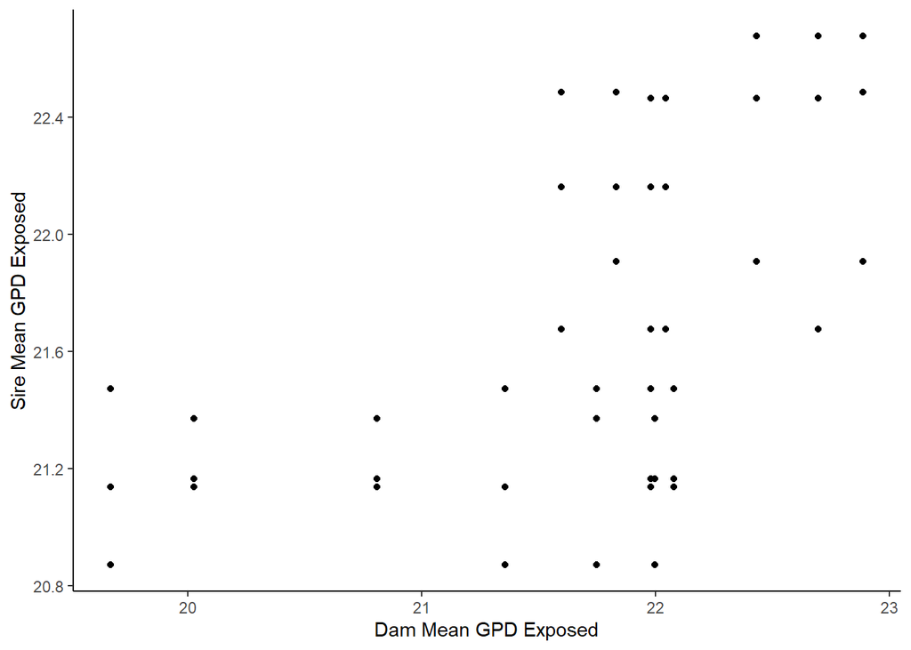

```r
ggplot(FamMeansWide, aes(y=SireGPDExp, x=DamGPDExp))+
  geom_point()+
   labs(x = "Dam Mean GPD Exposed", y= "Sire Mean GPD Exposed") +
  theme_classic()
```

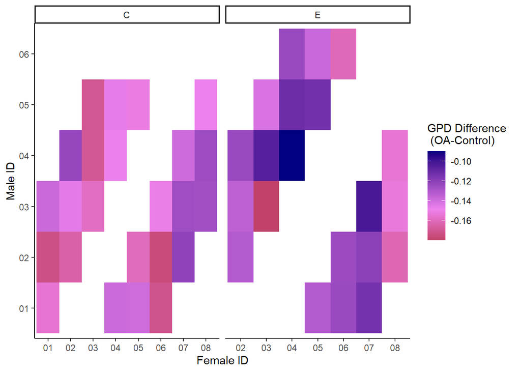

```r
#want to create a heatmap of difference in larval growth per day for each family. #first get just control families

FamMeansWide$FemIDPlain<- vapply(strsplit(as.character(FamMeansWide$FemaleID),"_"), `[`, 1, FUN.VALUE=character(1))
FamMeansWide$MaleIDPlain<- vapply(strsplit(as.character(FamMeansWide$MaleID),"_"), `[`, 1, FUN.VALUE=character(1))
FamMeansWide$MaleIDNumber<- substr(FamMeansWide$MaleIDPlain, 3, 4 )
FamMeansWide$FemaleIDNumber<- substr(FamMeansWide$FemIDPlain, 3, 4 )
FamMeansWide$ParTrt<- substr(FamMeansWide$MaleIDPlain, 1,1)
ConFamMeansWide<- filter(FamMeansWide, startsWith(as.character(FamMeansWide$CrossID), "C")== T)
ggplot(data = FamMeansWide) +                        # Set data
  geom_tile(aes(x = FemaleIDNumber, y = MaleIDNumber, fill = OACont_GPD)) +        # Define variables to plot
  scale_fill_gradient2(low = "darkred", mid="violet", high = "navyblue", midpoint=mean(ConFamMeansWide$OACont_GPD))+  # Set colour scheme
  facet_grid(~ParTrt, scale="free")+
  labs(x="Female ID", y= "Male ID", fill= "GPD Difference \n (OA-Control)")+
  theme_classic()
```

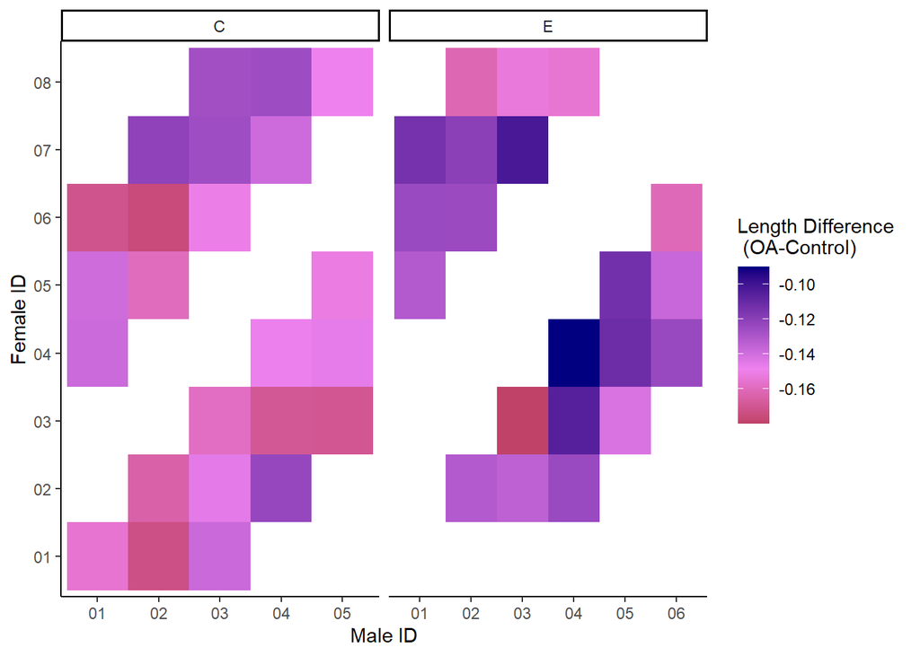

```r
  ggplot(data = FamMeansWide) +                        # Set data
  geom_tile(aes(x = MaleIDNumber, y = FemaleIDNumber, fill = OACont_Len)) +        # Define variables to plot
  scale_fill_gradient2(low = "darkred", mid="violet", high = "navyblue", midpoint=mean(ConFamMeansWide$OACont_Len))+  # Set colour scheme
  facet_grid(~ParTrt, scale="free")+
  labs(x="Male ID", y= "Female ID", fill= "Length Difference \n (OA-Control)")+
  theme_classic()
```

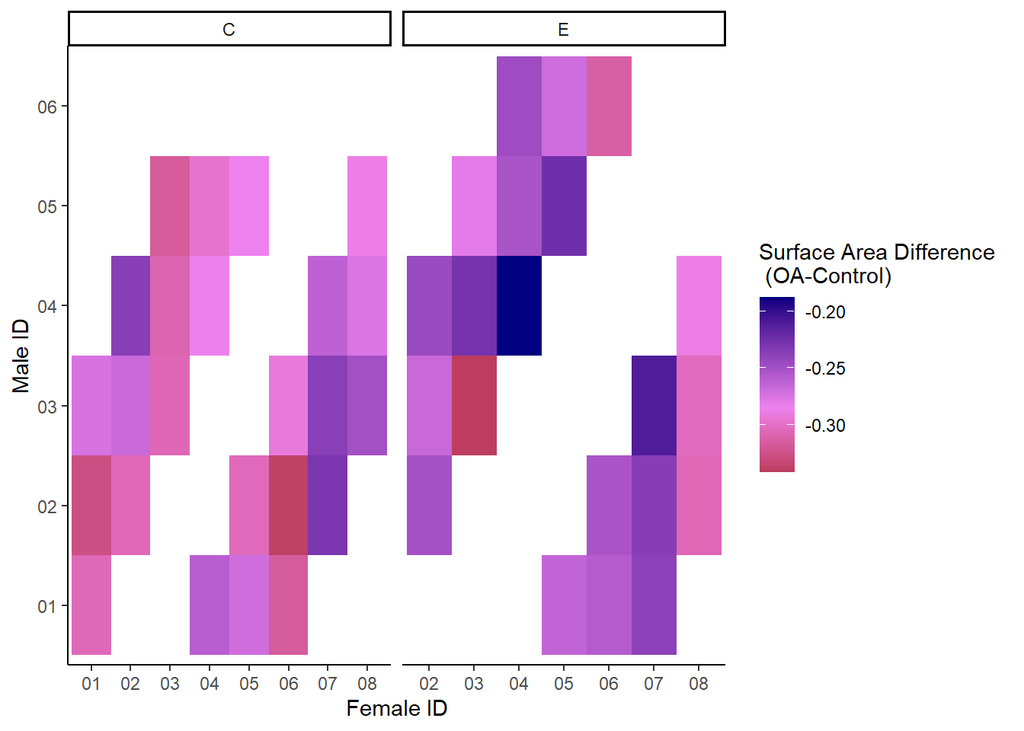

```r
ggplot(data = FamMeansWide) +                        # Set data
  geom_tile(aes(x = FemaleIDNumber, y = MaleIDNumber, fill = OACont_SA)) +        # Define variables to plot
  scale_fill_gradient2(low = "darkred", mid="violet", high = "navyblue", midpoint=mean(ConFamMeansWide$OACont_SA))+  # Set colour scheme
  facet_grid(~ParTrt, scale="free")+
  labs(x="Female ID", y= "Male ID", fill= "Surface Area Difference \n (OA-Control)")+
  theme_classic()
```

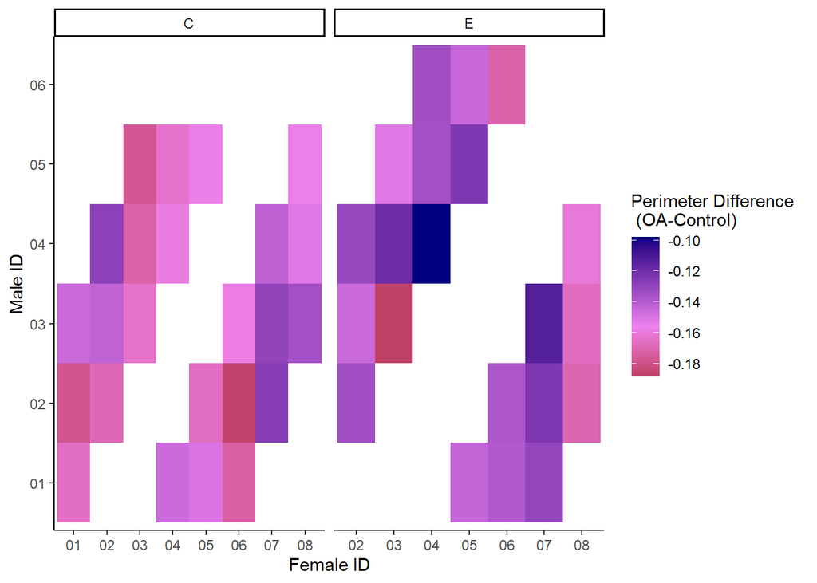

```r
  ggplot(data = FamMeansWide) +                        # Set data
  geom_tile(aes(x = FemaleIDNumber, y = MaleIDNumber, fill = OACont_P)) +        # Define variables to plot
  scale_fill_gradient2(low = "darkred", mid="violet", high = "navyblue", midpoint=mean(ConFamMeansWide$OACont_P))+  # Set colour scheme
  facet_grid(~ParTrt, scale="free")+
  labs(x="Female ID", y= "Male ID", fill= "Perimeter Difference \n (OA-Control)")+
  theme_classic()
```